# Convoy analysis

Eetu Mäkelä

2022-05-12

# General analysis

```r
tweets_c %>%
  count(original,name="tweets") %>%
  mutate(original=if_else(original==1,"original sample","expanded discussion")) %>%
  gt(rowname_col = "original") %>%
  fmt_integer(tweets) %>%
  summary_rows(columns=tweets, fns=list(total="sum"))
```

|  | tweets |
| --- | --- |
| original sample | 3,522,710 |
| expanded discussion | 17,062,094 |
| total | 20,584,804.00 |

Original sample is defined as follows:

```
twarc2 search –archive
–start-time ‘2022-01-22’ –end-time ‘2022-02-05’ ‘lang:en
(“#TruckersForFreedom” OR “#FreedomConvoy2022” OR “#TruckerConvoy2022”
OR “#NoVaccineMandate” OR “#ConvoyForFreedom” OR “#FreedomConvoyCanada”
OR “#FluTruxKlan” OR “#FluTrucksKlan” OR “#EndTheStigma” OR
“#TrudeauIsACoward” OR “#CowardOfCanada” OR “#ResignTrudeau” OR
“#Omicronvoy” OR “#OttawaOccupation” OR “#HonkHonk” OR “#honkhonk” OR
“#TruckersForFreedom2020” OR “#freedomconvoy” OR “#OttawaOccupied” OR
“#TrudeauMustResign” OR “#OttawaSiege” OR “#CanadaTruckers” OR
“#OttawaOccupiers” OR “#freedomconvoy22” OR “#TrudeauTyranny” OR
“#FluTruckKlan” OR “#GoHomeTruckers” OR “#ConvoyGoHome” OR
“#GoHomeFluTruxclan” OR “#flutrucksclangohome” OR “#freedumbConvoy2022”
OR “#Clownvoy” OR “#FluTruxKlanGoHome” OR “#GoHomeConvoy” OR
“#IAmVaxxed” OR “#ConvoyGoHome” OR “Go Home” OR “Canadian Trucking
Alliance” OR “PM Trudeau” OR “Prime Minister Justin Trudeau” OR “Prime
Minister”)’ convoy_2weeks.jsonl
```

## Raw access to the tweet data

The tweets are stored in a [MariaDB](https://mariadb.com/) (MySQL) database called `convoy` on host `vm1788.kaj.pouta.csc.fi`. The username for the database is `convoy`. The password is given separately. **DO NOT INCLUDE THE PASSWORD IN ANY CODE YOU COMMIT TO GITHUB**. If running this notebook, it will ask for the password the first time you run it, and then store it separately in your keyring.

Our raw data is both large and complex. With such data, one cannot unfortunately always just use a default database configuration and trust that it does the right thing. Therefore, here are some details:

- The data has been loaded into both Aria as well as [ColumnStore](https://mariadb.com/kb/en/mariadb-columnstore/) tables. Aria tables have a suffix of `_a` and ColumnStore tables a suffix of `_c`.
- Generally, ColumnStore tables should be more performant for the types of analytical queries we are performing, so use those as a default.
- However, for certain queries (at least including UNION ALL), the ColumnStore does weird things and is bog slow. For those, the `_a` variants may perform better.
- The ColumnStore does not support [recursive queries](https://mariadb.com/kb/en/recursive-common-table-expressions-overview/) useful for thread analysis. Therefore, these have to be computed using Aria `_a` tables.
- Mixing the two types of tables should often lead to worse performance (but may not)

The database structure is as follows:

- `tweets_[a|c]` is the main table holding the tweets as well as their statistics.
- `users_[a|c]` contains user information. It is linked from `tweets` by `author_id` and `in_reply_to_user_id`.
- `tweet_mentions_[a|c]` links `tweet_id`s to `user_id`s they mention.
- `tweet_hashtags_[a|c]` links `tweet_id`s to the hashtags they contain.
- `tweet_urls_[a|c]` links `tweet_id`s to the urls they contain.
- `conversations_[a|c]` contains conversation-level info and stats for each `conversation_id`.
- `ur_conversations_[a|c]` contains ur-conversation-level info and stats for each `ur_conversation_id`.

In the above, a *conversation* is a thread linked by `in_reply_to` links. In this view, whenever you retweet a tweet or quote-tweet it, you are starting a new, distinct converstaion instead of continuing an existing one. This is what the Twitter API deems a conversation and what their UI also generally shows, so a good view when examining conversations from a user’s perspective. However, when looking at a conversation in aggregate, one may also want to look at *all* conversation sparked by some message, and include downstream conversations started from retweets and quotes as well. For this, our data also includes an `ur_conversation_id`, which joins together all tweets in some way related to a single starter or its descendants, whether there are retweets or quote-tweets in the middle of that chain or not.

However, there is are two important caveats here:

1. When tweets/users get deleted by twitter, it breaks the conversation chain upwards from the deleted tweet. This affects both ur-conversation resolution as well as calculating conversation statistics.
2. It is possible for a tweet to be both a reply to a tweet as well as quote another tweet. For simplicity in this hackathon (for the conversations to remain clean trees instead of possibly cyclical DAGs), in such situations the tweet has **only** been associated with the ur-conversation to which it replies.

## Statistics for conversations and ur-conversations

The following statistics have been calculated for conversations and ur-conversations, and are available in the `tweets_[a|c]` table (remember that removed tweets can cause problems for most of these):

- `children`: the number of replies to this tweet
- `ur_children`: the number of retweets and quotes of, and replies to this tweet
- `descendants`: the total number of tweets after this one in the conversation
- `ur_descendants`: the total number of tweets after this one in the ur-conversation
- `leaf_descendants`: the total number of leaf tweets (tweets without further replies) in the conversation (a measure of conversation “breadth”)
- `ur_leaf_descendants`: the total number of leaf tweets (tweets without further replies) in the ur-conversation (a measure of ur-conversation “breadth”)
- `max_depth`: the maximum length reply chain discovered below this tweet
- `ur_max_depth`: the maximum length reply/retweet/quote chain discovered below this tweet
- `t_authors`: the total transitive amount of authors participating in the conversation branching down from this tweet
- `ur_t_authors`: the total transitive amount of authors participating in the ur-conversation branching down from this tweet
- `t_reply_count`: the total transitive reply count of the conversation branching down from this tweet (should be about equal to `descendants` if there are not too many missing tweets)
- `ur_t_reply_count`: the total transitive reply count of the ur-conversation branching down from this tweet
- `t_quote_count`: the total transitive quote count of the conversation branching down from this tweet
- `ur_t_quote_count`: the total transitive quote count of the ur-conversation branching down from this tweet
- `t_like_count`: the total transitive like count of the conversation branching down from this tweet
- `ur_t_like_count`: the total transitive like count of the ur-conversation branching down from this tweet
- `t_retweet_count`: the total transitive retweet count of the conversation branching down from this tweet
- `ur_t_retweet_count`: the total transitive retweet count of the ur-conversation branching down from this tweet
- `branching_factor`: the branching factor of the conversation tree, or the mean number of replies for each tweet that has replies
- `ur_branching_factor`: the branching factor of the ur-conversation tree, or the mean number of replies+quotes+retweets for each tweet that has them
- `mean_depth`: the mean depth of conversation branching down from this tweet
- `depth_mad`: the mean absolute deviation (a measure of variance) from the mean conversation depth
- `ur_mean_depth`: the mean depth of ur-conversation branching down from this tweet
- `ur_depth_mad`: the mean absolute deviation (a measure of variance) from the mean ur-conversation depth
- `mean_reply_count`: the mean count of replies for each tweet in the conversation branching down from this tweet
- `reply_count_mad`: the mean absolute deviation (a measure of variance) from the mean reply count
- `ur_mean_reply_count`: the mean count of replies for each tweet in the ur-conversation branching down from this tweet
- `ur_reply_count_mad`: the mean absolute deviation (a measure of variance) from the mean ur-conversation reply count
- `mean_quote_count`: the mean count of quotations of each tweet in the conversation branching down from this tweet
- `quote_count_mad`: the mean absolute deviation (a measure of variance) from the mean quotation count
- `ur_mean_quote_count`: the mean count of quotations of each tweet in the ur-conversation branching down from this tweet
- `ur_quote_count_mad`: the mean absolute deviation (a measure of variance) from the mean ur-conversation quotation count
- `mean_like_count`: the mean count of likes of each tweet in the conversation branching down from this tweet
- `like_count_mad`: the mean absolute deviation (a measure of variance) from the mean conversation like count
- `ur_mean_like_count`: the mean count of likes of each tweet in the ur-conversation branching down from this tweet
- `ur_like_count_mad`: the mean absolute deviation (a measure of variance) from the mean ur-conversation like count
- `mean_retweet_count`: the mean count of retweets of each tweet in the conversation branching down from this tweet
- `retweet`_count_mad`: the mean absolute deviation (a measure of variance) from the mean conversation retweet count
- `ur_mean_retweet_count`: the mean count of retweets of each tweet in the ur-conversation branching down from this tweet
- `ur_retweet_count_mad`: the mean absolute deviation (a measure of variance) from the mean ur-conversation retweet count

## Using the data inside R

To get to know R `tidyverse`, here are some great tutorials:

- https://moderndive.com/index.html chapters 1-4 are the best intro into R and tidyverse that I know of.
- Then, if you’re interested in expanding your visual analysis capabilities, following up with https://socviz.co/ is good.
- Excellent cheatsheets to keep on hand or even print while learning: https://www.rstudio.com/resources/cheatsheets/
- And finally “R for Data Science” is a central work by the authors of the packages, but I don’t think as good as the above: https://r4ds.had.co.nz/. Can be used to supplement the modern dive if something remains unclear or needs deepening after that.

## Overall temporal outlook (note logarithmic y-scale)

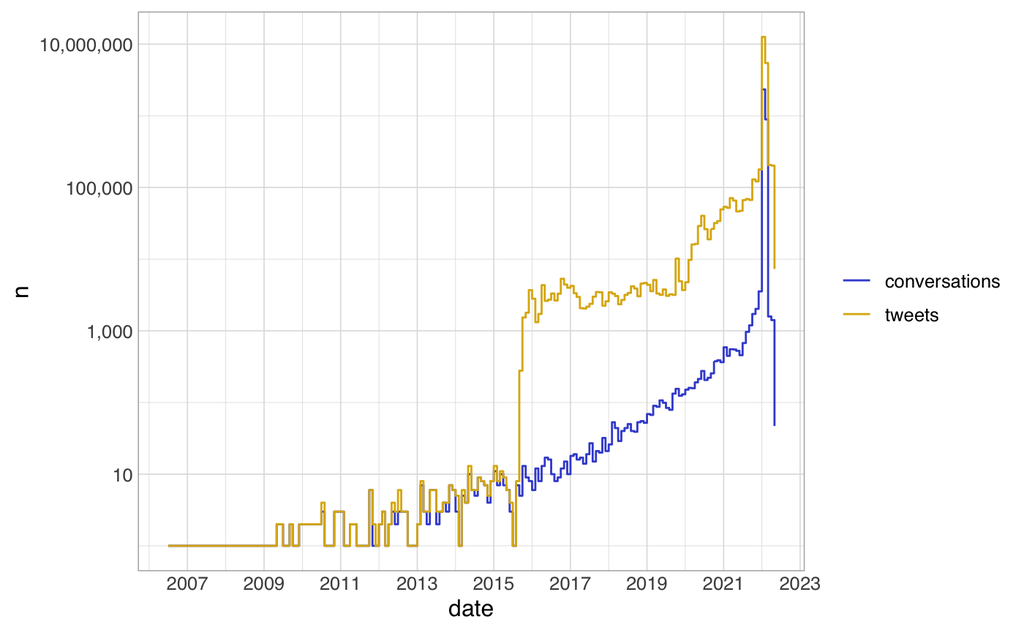

```r
tweets_c %>%
  count(year_created_at,month_created_at) %>%
  mutate(type="tweets") %>%
  collect() %>%
  bind_rows(
    tweets_c %>%
      filter(conversation_id==tweet_id) %>%
      count(year_created_at,month_created_at) %>%
      mutate(type="conversations") %>%
      collect()
  ) %>%
  mutate(date=make_date(year_created_at,month_created_at)) %>%
  ggplot(aes(x=date,y=n,color=type)) +
  geom_step() +
  theme_hsci_discrete() +
  scale_y_log10(labels=scales::comma) +
  labs(color=NULL) +
  scale_x_date(date_breaks="2 years",date_labels = "%Y")
```

# Freedom convoy -period (first two weeks)

## Total tweets in original sample

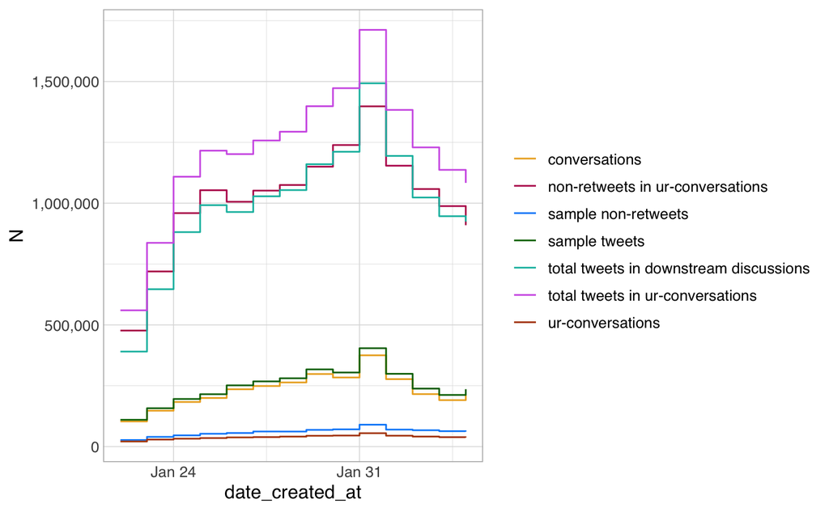

```r
tweets_c %>%
  filter(original,date_created_at>=as.Date("2022-01-22"),date_created_at<as.Date("2022-02-05")) %>%
  group_by(date_created_at) %>%
  summarize(`sample tweets`=n(), `sample non-retweets`=sum(is.na(retweet_of)), conversations=n_distinct(conversation_id), `ur-conversations`=n_distinct(ur_conversation_id),.groups="drop") %>%
  collect() %>%
  pivot_longer(`sample tweets`:`ur-conversations`) %>%
  bind_rows(
    tweets_c %>%
      filter(original,date_created_at>=as.Date("2022-01-22"),date_created_at<as.Date("2022-02-05")) %>%
      distinct(ur_conversation_id) %>%
      left_join(tweets_c,by=c("ur_conversation_id")) %>%
      filter(date_created_at>=as.Date("2022-01-22"),date_created_at<as.Date("2022-02-05")) %>%
      group_by(date_created_at) %>%
      summarize(`total tweets in ur-conversations`=n(), `non-retweets in ur-conversations`=sum(is.na(retweet_of))) %>%
      collect() %>%
      pivot_longer(`total tweets in ur-conversations`:`non-retweets in ur-conversations`)
  ) %>%
  bind_rows(
    tbl(con,sql('
      WITH RECURSIVE descendants AS (
        SELECT t.tweet_id
        FROM tweets_a t
        WHERE
          t.original=1
        UNION
        SELECT t.tweet_id
        FROM tweets_a t FORCE INDEX (in_reply_to), descendants d
        WHERE
          t.in_reply_to=d.tweet_id
      )
      SELECT date_created_at, COUNT(*) AS value
      FROM descendants INNER JOIN tweets_a USING (tweet_id)
      WHERE date_created_at>="2022-01-22" AND date_created_at<"2022-02-05"
      GROUP BY date_created_at
    ')) %>%
    collect() %>%
    mutate(name="total tweets in downstream discussions")
  ) %>%
  ggplot(aes(x=date_created_at,y=value,color=name)) +
  geom_step() +
  theme_hsci_discrete() +
  scale_y_continuous(labels=scales::comma) +
  labs(color=NULL) +
  ylab("N")
```

## Conversation length power-law

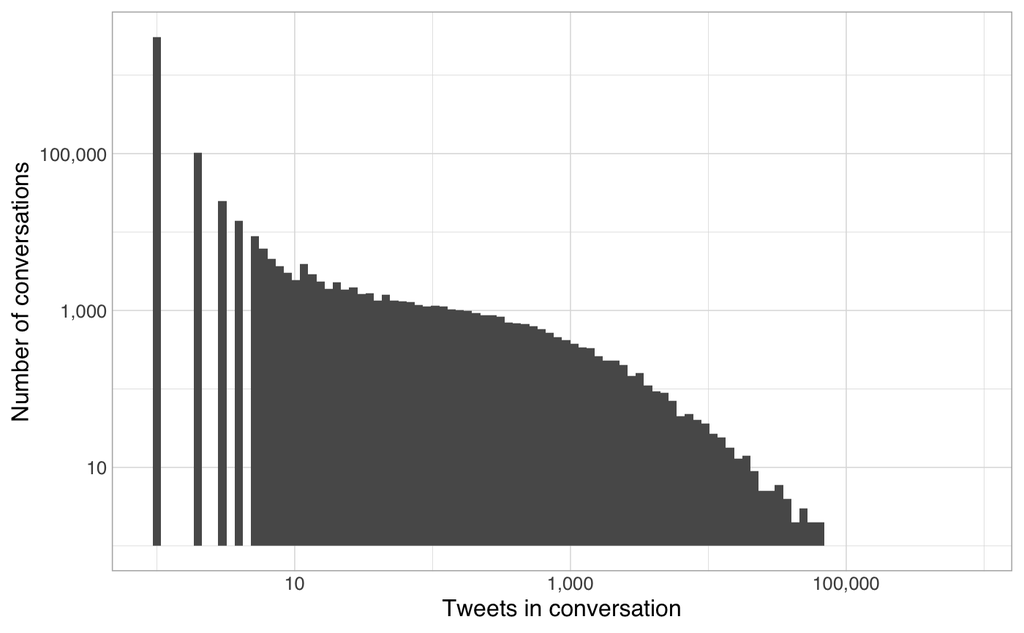

```r
tweets_c %>%
  count(conversation_id) %>%
  ggplot(aes(x=n)) +
  geom_histogram(bins=100) +
  scale_y_log10(labels=scales::comma) +
  scale_x_log10(labels=scales::comma) +
  theme_hsci_discrete() +
  ylab("Number of conversations") +
  xlab("Tweets in conversation")
```

```r
NA
```

A typical power-law relationship: there are a great many discussions with only a few replies, and very few discussions that go on forever

## Retweet/reply count relationship

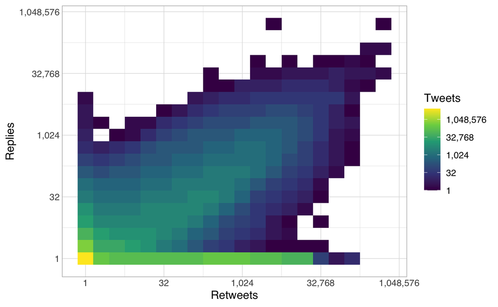

```r
tweets_c %>% mutate(
  rt_bin=floor(log2(retweet_count)),
  reply_bin=floor(log2(reply_count))
) %>%
  replace_na(list(rt_bin=0,reply_bin=0)) %>%
  count(rt_bin,reply_bin) %>%
  mutate(n_bin=floor(log2(n))) %>%
  ggplot(aes(x=rt_bin,y=reply_bin,fill=n_bin)) +
  geom_raster() +
  scale_x_continuous(labels=~scales::comma(2^.)) +
  scale_y_continuous(labels=~scales::comma(2^.)) +
  theme_hsci() +
  scale_fill_viridis_c(labels=~scales::comma(2^.)) +
  xlab("Retweets") +
  ylab("Replies") +
  labs(fill="Tweets")
```

It is quite possible for a tweet to garner a huge number of retweets without sparking any discussion. The opposite is much less likely. Apart from this, the number of retweets and replies is correlated.

# Some large conversations

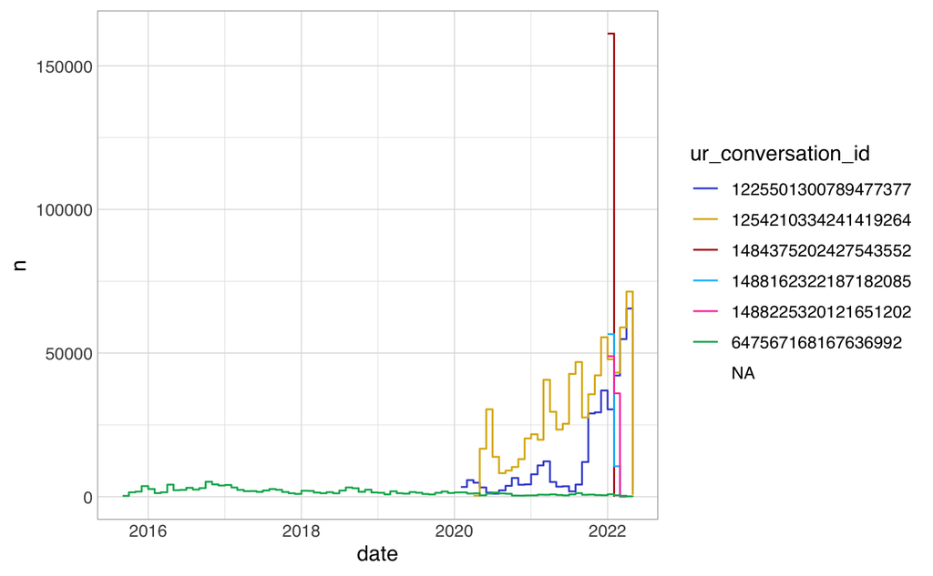

```r
d <- ur_conversations_c %>%
  arrange(desc(uc_ur_descendants)) %>%
  head(7) %>%
  select(ur_conversation_id) %>%
  left_join(tweets_c,by=c("ur_conversation_id")) %>%
  mutate(year=year(created_at),month=month(created_at)) %>%
  group_by(ur_conversation_id,year,month) %>%
  mutate(ur_conversation_id=as.character(ur_conversation_id)) %>%
  summarize(n=n(),authors=n_distinct(author_id),.groups="drop") %>%
  collect() %>%
  mutate(date=make_date(year,month))
d %>%
  ggplot(aes(x=date,y=n,color=ur_conversation_id)) +
  geom_step() +
  theme_hsci_discrete()
```

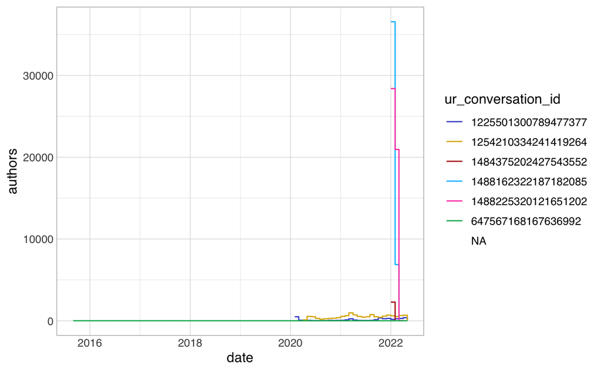

```r
d %>%
  ggplot(aes(x=date,y=authors,color=ur_conversation_id)) +
  geom_step() +
  theme_hsci_discrete()
```

```r
ur_conversations_c %>%
  arrange(desc(uc_ur_descendants)) %>%
  head(10) %>%
  select(ur_conversation_id,created_at,uc_ur_descendants,ur_descendants,ur_mean_reply_count,ur_mean_retweet_count) %>%
  left_join(tweets_c %>% group_by(ur_conversation_id) %>% summarize(authors=n_distinct(author_id)),by=c("ur_conversation_id")) %>%
  mutate(ur_conversation_id=str_c("[",ur_conversation_id,"](https://twitter.com/a/status/",ur_conversation_id,")")) %>%
  arrange(desc(uc_ur_descendants)) %>%
  collect() %>%
  relocate(authors,.after=ur_descendants) %>%
  gt() %>%
  fmt_markdown(ur_conversation_id) %>%
  fmt_integer(uc_ur_descendants:authors) %>%
  fmt_number(ur_mean_reply_count:ur_mean_retweet_count)
```

| ur_conversation_id | created_at | uc_ur_descendants | ur_descendants | authors | ur_mean_reply_count | ur_mean_retweet_count |
| --- | --- | --- | --- | --- | --- | --- |
| 1254210334241419264 | NA | 755,453 | NA | 5,765 | NA | NA |
|  | NA | 670,019 | NA | −2 | NA | NA |
| 1225501300789477377 | 2020-02-06 19:27:03 | 392,561 | 807 | 2,307 | 1.13 | 1.80 |
| 1484375202427543552 | 2022-01-21 04:00:00 | 161,228 | 155,876 | 2,287 | 1.02 | 0.02 |
| 647567168167636992 | 2015-09-26 00:23:03 | 129,905 | 129,714 | 10 | 1.00 | 0.00 |
| 1488225320121651202 | 2022-01-31 18:59:00 | 84,921 | 76,292 | 47,041 | 1.11 | 3.15 |
| 1488162322187182085 | 2022-01-31 14:48:04 | 67,226 | 62,325 | 42,641 | 1.11 | 1.63 |
| 1303426769127698432 | 2020-09-08 20:15:03 | 66,491 | 11 | 65 | 1.33 | 12.92 |
| 1486846468887560201 | 2022-01-27 23:39:05 | 61,803 | 57,124 | 39,485 | 1.41 | 3.37 |
| 1486772334635536395 | 2022-01-27 18:45:02 | 59,680 | 53,736 | 34,764 | 1.23 | 2.68 |

```r
descendants <- function(tweet_id) {
  tbl(con,sql(glue("
                   WITH RECURSIVE descendants AS (
                     SELECT t.tweet_id, 0 AS level
                     FROM tweets_a t
                     WHERE tweet_id={tweet_id}
                     UNION
                     SELECT t.tweet_id, d.level+1 AS level
                     FROM tweets_a t FORCE INDEX (in_reply_to), descendants d
                     WHERE t.in_reply_to=d.tweet_id
                   ) SELECT * FROM descendants")))
}
ur_conversations_c_i %>%
  arrange(desc(uc_ur_descendants)) %>%
  filter(!is.na(tweet_id)) %>%
  head(10) %>%
  select(tweet_id) %>%
  collect() %>%
  mutate(conversation=map(tweet_id,~descendants(.) %>%
                            head(20) %>%
                            select(tweet_id,level) %>%
                            left_join(tweets_a,by=c("tweet_id")) %>%
                            select(level,text) %>%
                            mutate(row_number=row_number()) %>%
                            collect())) %>%
  unnest_wider(conversation) %>%
  unnest_longer(level:row_number) %>%
  pivot_wider(names_from=tweet_id,values_from=text,id_cols=row_number) %>%
  select(-row_number) %>%
  gt()
```

| 1225501300789477377 | 1484375202427543552 | 647567168167636992 | 1488225320121651202 | 1488162322187182085 | 1303426769127698432 | 1486846468887560201 | 1486772334635536395 | 1488660359422648320 | 1485693066736402434 |
| --- | --- | --- | --- | --- | --- | --- | --- | --- | --- |
| The name "England" is derived from the Old English name Englaland, which means "land of the Angles". The Angles were one of the Germanic tribes that settled in Great Britain during the Early Middle Ag… | 🧡 ENHYPEN SIGNED ALBUM GIVEAWAY 🧡 Engene! Mimin mau GIVEAWAY SIGNED ALBUM ENHYPEN, DIMENSION: ANSWER nih! Caranya: 1. FOLLOW @ShopeeID 2. RT &amp; LIKE tweet ini 3. REPLY #ENHYPENdiSHOPEE YANG BANYAK!… | "Jamesy?..." | I know this pandemic is frustrating. It’s frustrating that, after two years, we’re not done fighting COVID-19. But over the past few days, Canadians have been shocked – and, frankly, disgusted – by th… | This morning, I tested positive for COVID-19. I’m feeling fine – and I’ll continue to work remotely this week while following public health guidelines. Everyone, please get vaccinated and get boosted. | @MilitaryStart4 @LLDMim @Chubbs172 @UNICORNPOOP99 @SPICYMOOSEBALLS @ToddHassinger11 @HeARTofGod99 @gnarlyballs @GODISBACK5 @GeishaJin @SmomMan @ltc_mim @colonel_light @Espo11Michael @THUNDERBOOM111 @H… | If you scare people enough, they will demand removal of freedom. This is the path to tyranny. | Canadian truckers rule | Today in the House, Members of Parliament unanimously condemned the antisemitism, Islamophobia, anti-Black racism, homophobia, and transphobia that we’ve seen on display in Ottawa over the past number… | Ahead of his show at the Walt Disney Concert Hall, Damon Albarn discusses his dual citizenship, the impending 25th anniversary of Blur’s self-titled 1997 LP and the legacy of the band’s biggest Americ… |
| @JamesMelville @schutzer9 time to wise up again I think BB | @ShopeeID wish me luckk #ENHYPENdiSHOPEE | @HisProtegee Yeah? | @JustinTrudeau What pandemic? https://twitter.com/Nogreatreset1/status/1488225534647705601/photo/1 | @JustinTrudeau https://twitter.com/DontCareAboutAF/status/1488162510184271878/photo/1 | @NoVaseline4you @MilitaryStart4 @LLDMim @chubbs172 @UNICORNPOOP99 @SPICYMOOSEBALLS @HeARTofGod99 @gnarlyballs @GODISBACK5 @GeishaJin @SmomMan @ltc_mim @colonel_light @Espo11Michael @THUNDERBOOM111 @He… | @elonmusk sounds like a mandate | @elonmusk Canada is a good place. | @JustinTrudeau LIAR. You will pay | Albarn also spills his thoughts on some of today's chart-topping music artists. Billie Eilish? "I think she’s exceptional." Taylor Swift? "She doesn’t write her own songs." https://www.latimes.com/ent… |
| @JamesMelville And 3 lions on the shirt is a Norman ( French ) sigil | @ShopeeID Yakin gue g menang | @JamesYourKing "I need a cuddle..." | @JustinTrudeau You are frustrating | @JustinTrudeau It’s the clown man https://twitter.com/TheHoboBaptist/status/1488162499643985920/photo/1 | @NoVaseline4you @MilitaryStart4 @LLDMim @chubbs172 @UNICORNPOOP99 @SPICYMOOSEBALLS @HeARTofGod99 @gnarlyballs @GODISBACK5 @GeishaJin @SmomMan @ltc_mim @colonel_light @Espo11Michael @THUNDERBOOM111 @He… | @elonmusk 100 percent true! | @elonmusk This NET is much cuter https://twitter.com/PigeonProject1/status/1486772492916203521/photo/1 | @JustinTrudeau https://twitter.com/FRINGEMlNORITY/status/1488660571520131076/photo/1 | And describes his sort of love-hate relationship with England. "England’s my home. However infuriating it is and however dumb the policies are, I am English." https://www.latimes.com/entertainment-art… |
| @JamesMelville Lala land right enough 😜 | @ShopeeID wish me luck #ENHYPENdiSHOPEE | @HisProtegee /Just/ a cuddle? | @JustinTrudeau Honk honk honk + ratio you dumb communist + Castro was your father | @JustinTrudeau Wishing you a swift recovery. | Somebody else reply to above twatt, only giving ME option to add more singular twatts | @elonmusk https://twitter.com/ThatCryptoFool1/status/1486846627017023489/photo/1 | @elonmusk So does Neil Young. | @JustinTrudeau Wow you are actually the biggest racist in Canada. There isn't any racism happening in Ottawa right now except from you. | Read the full exchange between @mikaelwood and Damon Albarn ➡️ https://www.latimes.com/entertainment-arts/music/story/2022-01-23/damon-albarn-blur-gorillaz https://twitter.com/latimes/status/148572974… |
| @JamesMelville Not to mean the German royalty | @ShopeeID #ENHYPENdiSHOPEE 4 | @JamesYourKing "I...yeah. Is that okay? I just need you to hold me right now..." | @JustinTrudeau https://twitter.com/CrossReverse/status/1488225451822784516/photo/1 | @JustinTrudeau I’m good thanks No experimental gene therapy for me https://twitter.com/COVID____1984/status/1488162515355766785/photo/1 | @NoVaseline4you @MilitaryStart4 @LLDMim @chubbs172 @UNICORNPOOP99 @SPICYMOOSEBALLS @HeARTofGod99 @gnarlyballs @GODISBACK5 @GeishaJin @SmomMan @ltc_mim @colonel_light @Espo11Michael @THUNDERBOOM111 @He… | @elonmusk https://twitter.com/BrownsCavsCats/status/1486846600848809992/photo/1 | @elonmusk Craft Crypto Color is presenting its Mandala Art #10. #handmade #nftart #NFTCommunity #NFT #Polygon #Matic Website: https://craftcryptocolor.com Buy or Bid Now: https://opensea.io/assets/mat… | @JustinTrudeau Your party refused to condemn blackface Was that your idea? | “Blur” turns 25 next month, but Albarn says he has no plans to mark the album’s anniversary. "I want nothing to do with any of it. Reissuing stuff that’s already had its moment is taking up space." ht… |
| @JamesMelville @kat_cary So that's why Mr Davis says the German car manufacturers are going to virtually pay us to take their cars so we can have an EU trade deal. We're all family. | @ShopeeID #ENHYPENdiSHOPEE 3 | @HisProtegee Yeah.. My lap is free? *He winks at her* Feel free.. Come and cuddle me up.. | I want to be very clear: We’re not intimidated by those who hurl abuse at small business workers and steal food from the homeless. We won’t give in to those who fly racist flags. And we won’t cave to … | @JustinTrudeau Boosted and still testing positive 😂😂 | @NoVaseline4you @MilitaryStart4 @LLDMim @chubbs172 @UNICORNPOOP99 @SPICYMOOSEBALLS @HeARTofGod99 @gnarlyballs @GODISBACK5 @GeishaJin @SmomMan @ltc_mim @colonel_light @Espo11Michael @THUNDERBOOM111 @He… | @elonmusk dude, fuck off. | @elonmusk https://twitter.com/Geolobo12/status/1486737112749772806?s=20 | @JustinTrudeau https://twitter.com/Day171Won/status/1488660445250699265/photo/1 | @latimes Go Home! |
| @JamesMelville And before that it was these guys here https://twitter.com/emotionalmammal/status/1225507709526642689/photo/1 | @ShopeeID yuk bisa yuk kali aja ditengok shopee #ENHYPENdiSHOPEE #ENHYPENdiSHOPEE #ENHYPENdiSHOPEE | @JamesYourKing She smiles softly and sits down on his lap, curling up against him as her arms wrap around him and she presses her face - | @JustinTrudeau You know damned well those are not protesters but planted PROVOCATEURS...whether instructed by you or your minions is another matter...don't try that old chestnut, its been done already… | @JustinTrudeau Did you also test positive for being a bitch? | @NoVaseline4you @MilitaryStart4 @LLDMim @chubbs172 @UNICORNPOOP99 @SPICYMOOSEBALLS @HeARTofGod99 @gnarlyballs @GODISBACK5 @GeishaJin @SmomMan @ltc_mim @colonel_light @Espo11Michael @THUNDERBOOM111 @He… | @elonmusk Unfortunately it is like that | @elonmusk Romanian stole ruls | @JustinTrudeau Come home justin we’re worried sick | NA |
| @JamesMelville Isn’t Englaland a recent, popular musical film staring @BorisJohnson and @theresa_may ? #LALALAND | @ShopeeID #ENHYPENdiSHOPEE 1 | @JamesYourKing -against his chest, letting out a shaky sigh. | @JustinTrudeau https://twitter.com/FRINGEMlNORITY/status/1488225492100685829/photo/1 | @JustinTrudeau @CameronAhmad #liar #CowardOfTheCottage | @toddhassinger11 @NoVaseline4you @MilitaryStart4 @LLDMim @chubbs172 @UNICORNPOOP99 @SPICYMOOSEBALLS @HeARTofGod99 @gnarlyballs @GODISBACK5 @GeishaJin @SmomMan @ltc_mim @colonel_light @Espo11Michael @T… | @elonmusk Elon muskateer take us to mars already m8 | @elonmusk Elon, have you seen that?? Crazy Russian made a copy of the Starship and sent it to Mars!! :D https://www.youtube.com/watch?v=Dp4iQN-1MKQ&t=576s | @JustinTrudeau https://twitter.com/supercazzola773/status/1488660542055227392/photo/1 | NA |
| @JamesMelville Don't tell the Brexit fuckwits they descend from Germanic tribes or, God forbid, anything French. They're not comfortable with facts and they'll be burning history books faster than you… | @ShopeeID #ENHYPENdiSHOPEE | @HisProtegee So what's the matter, babe? *He kisses her cheek and smiles softly* Something you want to tell me? | @JustinTrudeau Only a fringe minority have | @JustinTrudeau Stay safe PMJT. 🙏🙏 | @toddhassinger11 @MilitaryStart4 @LLDMim @chubbs172 @UNICORNPOOP99 @SPICYMOOSEBALLS @HeARTofGod99 @gnarlyballs @GODISBACK5 @GeishaJin @SmomMan @ltc_mim @colonel_light @Espo11Michael @THUNDERBOOM111 @H… | @elonmusk Buy my club pls | @elonmusk thank you | @JustinTrudeau Yet your party blocked a motion to condemn blackface? Curious HONK HONK HONK HONK HONK HONK HONK HONK HONK HONK HONK HONK HONK | NA |
| @JamesMelville Yes and lots of Viking genes in the mix too, plus of course the French Norman invaders amongst others. And this great genetic mix has always been a great strength of this little country… | @ShopeeID #ENHYPENdiSHOPEE | @JamesYourKing "No...I just...I need a hug." She says in a high pitched voice as tears start filling her eyes. | @JustinTrudeau HONKHONK | @JustinTrudeau Hopefully your not feeling so good that’s karma | @toddhassinger11 @NoVaseline4you @MilitaryStart4 @LLDMim @chubbs172 @UNICORNPOOP99 @SPICYMOOSEBALLS @HeARTofGod99 @gnarlyballs @GODISBACK5 @GeishaJin @SmomMan @ltc_mim @colonel_light @Espo11Michael @H… | @elonmusk Where’s doge? | @elonmusk Dumbass. | @JustinTrudeau https://twitter.com/dinges733/status/1488660508282699778/photo/1 | NA |
| @JamesMelville And Scotland is land of a Northern Irish tribe! | @ShopeeID #ENHYPENdiSHOPEE #ENHYPENdiSHOPEE #ENHYPENdiSHOPEE #ENHYPENdiSHOPEE #ENHYPENdiSHOPEE #ENHYPENdiSHOPEE #ENHYPENdiSHOPEE #ENHYPENdiSHOPEE #ENHYPENdiSHOPEE #ENHYPENdiSHOPEE #ENHYPENdiSHOPEE #EN… | @HisProtegee Why..? What's wrong. If you think I can't tell when you're upset by now.. Then you're the stupid one. | @JustinTrudeau Lies lies lies lies lies lies lies lies lies lies lies lies lies lies lies lies lies lies lies lies lies lies lies lies lies lies lies lies lies lies lies lies lies lies lies lies lies … | @JustinTrudeau https://twitter.com/jackravager/status/1488162460636880900/photo/1 | @LIGHTNINGBOOM1 @NoVaseline4you @MilitaryStart4 @LLDMim @chubbs172 @UNICORNPOOP99 @SPICYMOOSEBALLS @HeARTofGod99 @gnarlyballs @GODISBACK5 @GeishaJin @SmomMan @ltc_mim @colonel_light @Espo11Michael @TH… | @elonmusk Have no fear! | @elonmusk When Indian truckers rule?? | @JustinTrudeau Lol and then you spoke up and said you wouldn't condemn black face bahahaha your such a joke | NA |
| @JamesMelville I love telling those who say I'm an Anglo-Saxon that my Dad's family came from South Yorkshire /North Lincolnshire - the land of tha Angles and my Mum's from Saxony in Germany. They hat… | @ShopeeID aku menang sih fix #ENHYPENdiSHOPEE | @JamesYourKing "I honestly don't know...but I've been feeling like shit lately...could be my stupid period." She snorts. | @JustinTrudeau https://youtu.be/jXXemtKz-Oo | @JustinTrudeau Who you calling racist? https://twitter.com/pipelinebandit/status/1488162436930752514/photo/1 | @THUNDERBOOM111 @NoVaseline4you @MilitaryStart4 @LLDMim @chubbs172 @UNICORNPOOP99 @SPICYMOOSEBALLS @HeARTofGod99 @gnarlyballs @GODISBACK5 @GeishaJin @SmomMan @ltc_mim @colonel_light @Espo11Michael @He… | @elonmusk While the BNB is growing🔜🌙 https://www.youtube.com/watch?v=Qr9UlwnhlKQ&feature=youtu.be | @elonmusk #bitgert @elonmusk | @JustinTrudeau RESIGN!!!!!!!! | NA |
| @JamesMelville So that will explain the obsession with German cars shoes and supermarkets then! | @ShopeeID #ENHYPENdiSHOPEE | @HisProtegee Yeah... Are you on now? *He strokes her thighs* You don't feel too good do you? | @JustinTrudeau Imagine someone that has repeatedly done blackface calling a peaceful protest racist LOL. The hypocrisy is hilarious. | @JustinTrudeau Pussy | NA | @elonmusk Expose it all Elon. PLEEEEEASSE. | @elonmusk What I’ve seen was direct from the creator of MicroStrategy! https://twitter.com/LucilleParr/status/1486772447349194752/photo/1 | @JustinTrudeau https://twitter.com/GarcettiTyga/status/1488660434928418816/photo/1 | NA |
| @JamesMelville And, even then, it wasn't a single, united entity. That didn't really even start until after the Normans decided to come visit. | @ShopeeID #ENHYPENdiSHOPEE | @JamesYourKing "Yeah...I am...and my tummy hurts and all I want to do is stay in bed all day..." she murmurs. "Sorry..." she sighs. | @JustinTrudeau WRONG- freedom is not negotiable | @JustinTrudeau https://twitter.com/HodlAlabama/status/1488162508330479618/photo/1 | NA | @elonmusk Fearmongering works great on simple minds. | @elonmusk musk | @JustinTrudeau That one guy? Where are you seeing this??? | NA |
| @JamesMelville @FergusonPhilip Are you using Twitter to make notes for your history GCSE? | @ShopeeID bismillah dulu wish me luck #ENHYPENdiSHOPEE | @HisProtegee Don't be sorry, beautiful... *He strokes her hair and kisses her cheek* I love you to bits... I love you so much.. | @JustinTrudeau Intolerant and anti-science segregationist. You are the minority. | @JustinTrudeau Get well soon Prime Minister | NA | @elonmusk Then let’s oppose tyranny whenever we encounter it. | @elonmusk Looking for a better way to make friends when wearamask? Join free app Bost to easily and safely connect with new friends nearby. Download for free at Apple https://apps.apple.com/us/app/bos… | @JustinTrudeau Bullshit | NA |
| @JamesMelville Land of a German tribe is it? Would have loved to see you put that one past Alfred. | @ShopeeID #ENHYPENdiSHOPEE | @JamesYourKing "I love you too..." she whispers, moving her head to lean up and peck his lips. | @JustinTrudeau https://twitter.com/KevinFCurry8091/status/1488225526649085953/photo/1 | @JustinTrudeau Wishing you and your entire family a speedy recovery. | NA | @elonmusk Omg first | @elonmusk اص انت | @JustinTrudeau Are you High?? That's all made up bullshit. | NA |
| @JamesMelville What’s your point James? Yes, we know Britain is a ‘Heinz 57’ variety. We’re leaving the EU, not planet Earth! | @ShopeeID #ENHYPENdiSHOPEE | @HisProtegee *He looks up at her and pulls her in for a close cuddle* Tell you what, you go and get some blankets and I'll make it up - | @JustinTrudeau HONK HONK HONK HONK HONK | @JustinTrudeau Take care of yourself PM. Hope it passes quickly. | NA | @elonmusk AGREE!! | @elonmusk What about Canadian bacon | @JustinTrudeau Can it coward of the cottage | NA |
| @JamesMelville Just as the English language is actually derived from a German dialect. | @ShopeeID #ENHYPENdiSHOPEE AYO MIN PICK ME!!!! NNTI AKU KAYANG DI DEPAN KOMPLEK WKWKWKWK | @HisProtegee -nice and cosy.. and get you a hot water bottle.. We'll have a movie day okay?.. | @JustinTrudeau I'm disgusted you are the Prime Minister of Canada. | @JustinTrudeau Get better soon! | NA | @elonmusk Fds, ngm liga 👍🏽 | @elonmusk #GREENCHARTbsc 💚🍀💚 | @JustinTrudeau Here, humanity is facing the oppression, they want to stop the voices of refugees, not to let the cry of justice be heard, not to speak of their more than 20 years of oppression, not to… | NA |
| @JamesMelville Yes may i remind you also the Normans ( vikings) invaded 1066. It was a ruthless invasion killing all opposition and to this day they still own 80 percent of the land | @ShopeeID #ENHYPENdiSHOPEE | @JamesYourKing Her lips curl up into a smile as she nods excitedly. "Yeah...that sounds perfect, baby...thank you so much..That's exactly - | @JustinTrudeau https://twitter.com/FRINGEMlNORITY/status/1488225514942828549/photo/1 | @JustinTrudeau Thank God your triple vaxxed can we get on with our lives please? | NA | @elonmusk You're the man ! | @elonmusk @DogediToken | @JustinTrudeau https://twitter.com/covid____1984/status/1488425534358913029?s=21 | NA |
| @JamesMelville I also believe that the Scottish term ‘Sasanach’ derives from ‘Saxon‘ another tribe/group from northern Germany. | @ShopeeID #ENHYPENdiSHOPEE 2 | @JamesYourKing -what I need right now." | @JustinTrudeau What is this then? https://twitter.com/thatsgouveia/status/1488225470609039365/photo/1 | @JustinTrudeau Eat 💩💩💩💩💩 | NA | @elonmusk Yes 🇨🇦 | @elonmusk Hi Musk | @JustinTrudeau If you think that's the main concern you really need to get your head outta your ass.. | NA |

## Conversation 1254210334241419264 - the MOAC (Mother of All [Climate Change + Spam] Conversations)

```r
tweets_c_i %>%
  filter(ur_conversation_id==sql("1254210334241419264")) %>%
  summarize(
    tweets=n(),
    tweets_with_keywords=sum(original),
    authors=n_distinct(author_id),
    min_date=min(created_at),
    max_date=max(created_at)
  ) %>% collect() %>%
  bind_cols(
    tweets_c_i %>%
      filter(ur_conversation_id==sql("1254210334241419264")) %>%
      count(author_id,name="tweets_per_author") %>%
      mutate(m_t_p_a=mean(tweets_per_author)) %>%
      summarize(mean_tweets_per_author=mean(tweets_per_author),tweets_per_author_mean_absolute_deviation=mean(abs(m_t_p_a-tweets_per_author))) %>% collect()
  ) %>%
  gt()
```

| tweets | tweets_with_keywords | authors | min_date | max_date | mean_tweets_per_author | tweets_per_author_mean_absolute_deviation |
| --- | --- | --- | --- | --- | --- | --- |
| 755453 | 13 | 5765 | 2020-04-26 02:08:04 | 2022-05-01 12:09:01 | 131.0413 | 230.2196 |

### First 20 tweets

```r
tweets_c_i %>%
  filter(ur_conversation_id==sql("1254210334241419264")) %>%
  left_join(users_c_i,by=c("author_id"="user_id")) %>%
  arrange(created_at.x) %>%
  head(20) %>%
  mutate(tweet_id=str_c("[",tweet_id,"](https://twitter.com/a/status/",tweet_id,")")) %>%
  mutate(conversation_id=str_c("[",conversation_id,"](https://twitter.com/a/status/",conversation_id,")")) %>%
  mutate(ur_conversation_id=str_c("[",ur_conversation_id,"](https://twitter.com/a/status/",ur_conversation_id,")")) %>%
  gt() %>%
  fmt_markdown(tweet_id|conversation_id|ur_conversation_id)
```

| tweet_id | ur_conversation_id | conversation_id | author_id | created_at.x | retweet_count | reply_count | like_count | quote_count | lang | text | in_reply_to | in_reply_to_user_id | quotes | retweet_of | error.x | error_detail.x | original | hashtags | urls | mentions | children | ur_children | descendants | ur_descendants | leaf_descendants | ur_leaf_descendants | max_depth | ur_max_depth | t_authors | … |
| --- | --- | --- | --- | --- | --- | --- | --- | --- | --- | --- | --- | --- | --- | --- | --- | --- | --- | --- | --- | --- | --- | --- | --- | --- | --- | --- | --- | --- | --- | --- |
| 1254230910527995905 | 1254210334241419264 | 1254210334241419264 | 186701910 | 2020-04-26 02:08:04 | 0 | 2 | 5 | 0 | en | @RoyPentland @rockcitymark You mean al gore who basically invented big business climate change so he didn’t have to get a real job? That al gore? | 1254210334241419264 | 1014798415991959552 | NA | NA | NA | NA | 0 | NA | NA | 2 | 1 | 1 | 1 | 1 | 1 | 1 | 1 | 1 | 2 | … |
| 1254231723614834688 | 1254210334241419264 | 1254210334241419264 | 186701910 | 2020-04-26 02:12:00 | 0 | 0 | 0 | 0 | en | @RoyPentland @rockcitymark Yup same guy lol | 1254231551295905792 | 1014798415991959552 | NA | NA | NA | NA | 0 | NA | NA | 2 | 0 | 0 | 0 | 0 | 0 | 0 | 0 | 0 | 1 | … |
| 1254232594574643200 | 1254210334241419264 | 1254210334241419264 | 186701910 | 2020-04-26 02:15:02 | 0 | 1 | 0 | 0 | en | @RoyPentland @rockcitymark I read your profile i was a tool and die maker and had to retrain in QC because of an accident now I own a few businesses but im very familiar with quality systems mostly au… | 1254231551295905792 | 1014798415991959552 | NA | NA | NA | NA | 0 | NA | NA | 2 | 0 | 0 | 0 | 0 | 0 | 0 | 0 | 0 | 1 | … |
| 1254234815144001541 | 1254210334241419264 | 1254210334241419264 | 186701910 | 2020-04-26 02:24:01 | 0 | 1 | 0 | 0 | en | @RoyPentland @rockcitymark Nice to meet unas well. Ya i hear that lol it can be monotonous for sure all the paperwork but interesting at auditing levels but ill bet you miss engineering sometimes i mi… | 1254233638893322240 | 1014798415991959552 | NA | NA | NA | NA | 0 | NA | NA | 2 | 0 | 0 | 0 | 0 | 0 | 0 | 0 | 0 | 1 | … |
| 1254268118790258690 | 1254210334241419264 | 1254210334241419264 | 1158139433511768065 | 2020-04-26 04:36:03 | 11 | 0 | 17 | 1 | en | @RoyPentland @RokoshME Lucky for the climate cult and its rich insiders theres lots of fossil fuels to create and keep running all the scams they can possibly dream up. Billions more to be made! Thank… | 1254210334241419264 | 1014798415991959552 | NA | NA | NA | NA | 0 | NA | 1 | 1 | 0 | 0 | 0 | 0 | 0 | 0 | 0 | 0 | 1 | … |
| 1254276410727903232 | 1254210334241419264 | 1254210334241419264 | 186701910 | 2020-04-26 05:09:03 | 0 | 0 | 0 | 0 | en | @RoyPentland @rockcitymark Cool mark hope to see some of your tweets be good nice to meet you | 1254268597087596544 | 1014798415991959552 | NA | NA | NA | NA | 0 | NA | NA | 2 | 0 | 0 | 0 | 0 | 0 | 0 | 0 | 0 | 1 | … |
| 1254292606692945922 | 1254210334241419264 | 1254210334241419264 | 1018662061461696512 | 2020-04-26 06:13:05 | 1 | 1 | 6 | 0 | en | @RoyPentland Gawd, if we could convert the hot air coming from Al and his Goron acolytes to 'humothermal energy',(see how I just made up that word) humanities energy needs could be met for the next th… | 1254210334241419264 | 1014798415991959552 | NA | NA | NA | NA | 0 | NA | NA | 1 | 0 | 0 | 0 | 0 | 0 | 0 | 0 | 0 | 1 | … |
| 1254293025011851265 | 1254210334241419264 | 1254210334241419264 | 1018662061461696512 | 2020-04-26 06:15:03 | 0 | 0 | 0 | 0 | en | @stevenjfraser @RoyPentland @rockcitymark Very same one. | 1254230910527995905 | 186701910 | NA | NA | NA | NA | 0 | NA | NA | 3 | 0 | 0 | 0 | 0 | 0 | 0 | 0 | 0 | 1 | … |
| 1254295747438075906 | 1254210334241419264 | 1254210334241419264 | 1018662061461696512 | 2020-04-26 06:26:02 | 0 | 1 | 0 | 0 | en | @RoyPentland I have my moments. | 1254293888459632640 | 1014798415991959552 | NA | NA | NA | NA | 0 | NA | NA | 1 | 1 | 1 | 1 | 1 | 1 | 1 | 1 | 1 | 2 | … |
| 1254312845962956806 | 1254210334241419264 | 1254210334241419264 | 823798315724607488 | 2020-04-26 07:34:02 | 0 | 1 | 0 | 0 | en | @RoyPentland Yes. We just have to make it all green. Which we can do? | 1254210334241419264 | 1014798415991959552 | NA | NA | NA | NA | 0 | NA | NA | 1 | 0 | 0 | 0 | 0 | 0 | 0 | 0 | 0 | 1 | … |
| 1254346832806916096 | 1254210334241419264 | 1254210334241419264 | 2389457995 | 2020-04-26 09:49:02 | 0 | 8 | 1 | 1 | en | @RoyPentland @KeillerDon 8-9 billion humans would deplete the lower cost fossil fuels at such a high rate that an energy crisis would arise by 2075, because billions wouldn't be able to afford the pri… | 1254210334241419264 | 1014798415991959552 | NA | NA | NA | NA | 0 | NA | NA | 2 | 6 | 6 | 7 | 7 | 6 | 6 | 2 | 2 | 7 | … |
| 1254349959316615169 | 1254210334241419264 | 1254210334241419264 | 2389457995 | 2020-04-26 10:01:04 | 0 | 6 | 2 | 1 | en | @RoyPentland @KeillerDon Based on my data. I have studied this problem for a long time. The key is to understand the industry, and how the quality of resources continues to drop, demanding higher and … | 1254347458269741058 | 1014798415991959552 | NA | NA | NA | NA | 0 | NA | 1 | 2 | 2 | 2 | 2 | 2 | 2 | 2 | 1 | 1 | 3 | … |
| 1254354495145984002 | 1254210334241419264 | 1254210334241419264 | 451776898 | 2020-04-26 10:19:05 | 44 | 10 | 73 | 6 | en | @RoyPentland @FernandoLeanme @KeillerDon Known coal reserves for thousands of years. New research shows unmeasured huge amount of petroleum oozing out from the ocean bed every where. https://twitter.c… | 1254351156068806656 | 1014798415991959552 | NA | NA | NA | NA | 0 | NA | 1 | 3 | 4 | 4 | 7 | 7 | 5 | 5 | 3 | 3 | 6 | … |
| 1254356096732598273 | 1254210334241419264 | 1254210334241419264 | 451776898 | 2020-04-26 10:26:01 | 0 | 0 | 2 | 0 | en | @RoyPentland @FernandoLeanme @KeillerDon Welcome, Roy. | 1254355352960679938 | 1014798415991959552 | NA | NA | NA | NA | 0 | NA | NA | 3 | 0 | 0 | 0 | 0 | 0 | 0 | 0 | 0 | 1 | … |
| 1254357424871481344 | 1254210334241419264 | 1254210334241419264 | 451776898 | 2020-04-26 10:31:02 | 0 | 0 | 0 | 0 | und | @RoyPentland @JaggerMickOZ @FernandoLeanme @KeillerDon 🙏🇦🇺🇺🇸 | 1254356381567553536 | 1014798415991959552 | NA | NA | NA | NA | 0 | NA | NA | 4 | 0 | 0 | 0 | 0 | 0 | 0 | 0 | 0 | 1 | … |
| 1254358250708926464 | 1254210334241419264 | 1254210334241419264 | 984037907454418944 | 2020-04-26 10:34:04 | 0 | 2 | 0 | 0 | en | @RoyPentland @JaggerMickOZ sure Roelof, never mind science ... https://www.youtube.com/watch?v=F8ZJCtL6bPs&t=533s | 1254210334241419264 | 1014798415991959552 | NA | NA | NA | NA | 0 | NA | 1 | 2 | 0 | 0 | 0 | 0 | 0 | 0 | 0 | 0 | 1 | … |
| 1254360307767693314 | 1254210334241419264 | 1254210334241419264 | 2389457995 | 2020-04-26 10:42:05 | 0 | 2 | 0 | 0 | en | @drwaheeduddin @RoyPentland @KeillerDon Sorry Doc, but the fact is that reservoir quality has been dropping relentlessly for 40 years, today exploration for oil doesn't find enough to replace what's b… | 1254354495145984002 | 451776898 | NA | NA | NA | NA | 0 | NA | NA | 3 | 1 | 1 | 3 | 3 | 2 | 2 | 2 | 2 | 3 | … |
| 1254361170993086469 | 1254210334241419264 | 1254210334241419264 | 451776898 | 2020-04-26 10:46:02 | 1 | 2 | 6 | 0 | en | @FernandoLeanme @RoyPentland @KeillerDon You don't believe in IEA? Let me invite an experienced petroleum engineer @GillesnFio to educate us on the current status of oil and gas reservoirs and explora… | 1254360307767693314 | 2389457995 | NA | NA | NA | NA | 0 | NA | NA | 4 | 2 | 2 | 2 | 2 | 2 | 2 | 1 | 1 | 3 | … |
| 1254362215798489090 | 1254210334241419264 | 1254210334241419264 | 451776898 | 2020-04-26 10:50:03 | 0 | 0 | 5 | 0 | und | @JaggerMickOZ @RoyPentland @FernandoLeanme @KeillerDon @JWSpry @Canberroo @AndyOz2 @SylviaD32911201 @KiryeNet @EcoSenseNow @Kenneth72712993 @dbirch214 @StormSignalSA @DawnTJ90 @tan123 @Piers_Corbyn @N… | 1254361274139308034 | 2289423523 | NA | NA | NA | NA | 0 | NA | NA | 18 | 0 | 0 | 0 | 0 | 0 | 0 | 0 | 0 | 1 | … |
| 1254368119092543489 | 1254210334241419264 | 1254210334241419264 | 451776898 | 2020-04-26 11:13:05 | 0 | 1 | 4 | 0 | en | @JaggerMickOZ @RoyPentland @FernandoLeanme @KeillerDon @JWSpry @Canberroo @AndyOz2 @SylviaD32911201 @KiryeNet @EcoSenseNow @Kenneth72712993 @dbirch214 @StormSignalSA @DawnTJ90 @tan123 @Piers_Corbyn @N… | 1254361274139308034 | 2289423523 | NA | NA | NA | NA | 0 | NA | NA | 18 | 1 | 1 | 1 | 1 | 1 | 1 | 1 | 1 | 2 | … |

### Random 20 tweets

```r
tweets_c_i %>%
  filter(ur_conversation_id==sql("1254210334241419264")) %>%
  arrange(sql("RAND()")) %>%
  head(20) %>%
  arrange(created_at) %>%
  left_join(users_c_i,by=c("author_id"="user_id")) %>%
  mutate(tweet_id=str_c("[",tweet_id,"](https://twitter.com/a/status/",tweet_id,")")) %>%
  mutate(conversation_id=str_c("[",conversation_id,"](https://twitter.com/a/status/",conversation_id,")")) %>%
  mutate(ur_conversation_id=str_c("[",ur_conversation_id,"](https://twitter.com/a/status/",ur_conversation_id,")")) %>%
  gt() %>%
  fmt_markdown(tweet_id|conversation_id|ur_conversation_id)
```

| tweet_id | ur_conversation_id | conversation_id | author_id | created_at.x | retweet_count | reply_count | like_count | quote_count | lang | text | in_reply_to | in_reply_to_user_id | quotes | retweet_of | error.x | error_detail.x | original | hashtags | urls | mentions | children | ur_children | descendants | ur_descendants | leaf_descendants | ur_leaf_descendants | max_depth | ur_max_depth | t_authors | … |
| --- | --- | --- | --- | --- | --- | --- | --- | --- | --- | --- | --- | --- | --- | --- | --- | --- | --- | --- | --- | --- | --- | --- | --- | --- | --- | --- | --- | --- | --- | --- |
| 1481652747304792065 | 1254210334241419264 | 1254210334241419264 | 154404648 | 2022-01-13 15:41:05 | 0 | 1 | 2 | 0 | en | @BrknMan @OscarsWild1 @Narvuntien @pauladamsalber1 @SniemN @IngersolRobert @rln_nelson @NoelTurner194 @MartinJBern @JohnDublin10 @MikeDel21893959 @RobMeekel @Canadianworker2 @jimdtweet @WayneAllanH @f… | 1481649900647424004 | 271132722 | NA | NA | NA | NA | 0 | NA | NA | 50 | 1 | 1 | 3 | 3 | 2 | 2 | 2 | 2 | 3 | … |
| 1481653447896154124 | 1254210334241419264 | 1254210334241419264 | 333001582 | 2022-01-13 15:44:04 | 0 | 2 | 2 | 0 | en | @robhon_ @ScienceBlog3 @JohnDublin10 @Kenneth72712993 @RobMeekel @Moderna5G_666 @ammocrypta @rln_nelson @4Clearsky @IanDJbrown2 @GlennCarr6 @HalBrow68884227 @sandcastle1975 @Willard1951 @BubbasRanch @… | 1481651580021575683 | 3313813825 | NA | NA | NA | NA | 0 | NA | NA | 48 | 1 | 1 | 27 | 27 | 6 | 6 | 15 | 15 | 6 | … |
| 1481635418193858566 | 1254210334241419264 | 1254210334241419264 | 3230235736 | 2022-01-13 14:33:00 | 0 | 1 | 2 | 0 | en | @Michael_D_Crow @MarshallCd @andrewp109 @gimmeabreak8 @ChrisBBacon3 @IngersolRobert @MikeDel21893959 @6lennybravo @aSinister @Anonylyzer13 @TypicalDeviant @QuBuBrasil @TheDisproof @_Ratzz_ @JimBowersc… | 1481634901350887430 | 822515689122447360 | NA | NA | NA | NA | 0 | NA | NA | 50 | 1 | 1 | 1 | 1 | 1 | 1 | 1 | 1 | 2 | … |
| 1487815089843408900 | 1254210334241419264 | 1254210334241419264 | 1004694289 | 2022-01-30 15:48:05 | 4 | 1 | 13 | 0 | en | @pauladamsalber1 @Narvuntien @wlbeeton @JohnDublin10 @Canadianworker2 @AristotleMrs @GerardMLaw @WayneAllanH @rln_nelson @StormSignalSA @ejwwest @MedBennett @jimdtweet @fergy1999 @GlennCarr6 @Tcaddy5 … | 1487814405794320387 | 3063921782 | NA | NA | NA | NA | 1 | 5 | 1 | 50 | 1 | 5 | 1 | 5 | 1 | 5 | 1 | 1 | 2 | … |
| 1487815498687340545 | 1254210334241419264 | 1487815498687340545 | 2228911879 | 2022-01-30 15:50:03 | 4 | 0 | 0 | 0 | en | RT @FriendsOScience: @pauladamsalber1 @Narvuntien @wlbeeton @JohnDublin10 @Canadianworker2 @AristotleMrs @GerardMLaw @WayneAllanH @rln_nels… | NA | NA | NA | 1487815089843408900 | NA | NA | 1 | NA | NA | 9 | 0 | 0 | 0 | 0 | 0 | 0 | 0 | 0 | 1 | … |
| 1487833633109028864 | 1254210334241419264 | 1487833633109028864 | 18673125 | 2022-01-30 17:02:03 | 4 | 0 | 0 | 0 | en | RT @FriendsOScience: @pauladamsalber1 @Narvuntien @wlbeeton @JohnDublin10 @Canadianworker2 @AristotleMrs @GerardMLaw @WayneAllanH @rln_nels… | NA | NA | NA | 1487815089843408900 | NA | NA | 1 | NA | NA | 9 | 0 | 0 | 0 | 0 | 0 | 0 | 0 | 0 | 1 | … |
| 1487830061315203072 | 1254210334241419264 | 1487830061315203072 | 1084911963317112832 | 2022-01-30 16:48:02 | 4 | 0 | 0 | 0 | en | RT @FriendsOScience: @pauladamsalber1 @Narvuntien @wlbeeton @JohnDublin10 @Canadianworker2 @AristotleMrs @GerardMLaw @WayneAllanH @rln_nels… | NA | NA | NA | 1487815089843408900 | NA | NA | 1 | NA | NA | 9 | 0 | 0 | 0 | 0 | 0 | 0 | 0 | 0 | 1 | … |
| 1481653578083160066 | 1254210334241419264 | 1254210334241419264 | 1084911963317112832 | 2022-01-13 15:45:01 | 0 | 0 | 1 | 0 | en | @robinlarder @Narvuntien @pauladamsalber1 @SniemN @BrknMan @IngersolRobert @rln_nelson @NoelTurner194 @MartinJBern @JohnDublin10 @MikeDel21893959 @RobMeekel @Canadianworker2 @jimdtweet @WayneAllanH @f… | 1481648250729861129 | 802620361 | NA | NA | NA | NA | 0 | NA | NA | 50 | 0 | 0 | 0 | 0 | 0 | 0 | 0 | 0 | 1 | … |
| 1481653841191784452 | 1254210334241419264 | 1254210334241419264 | 1084911963317112832 | 2022-01-13 15:46:01 | 0 | 1 | 1 | 0 | en | @Narvuntien @ScienceBlog3 @JohnDublin10 @Kenneth72712993 @RobMeekel @Moderna5G_666 @ammocrypta @rln_nelson @4Clearsky @IanDJbrown2 @GlennCarr6 @merphie77 @robhon_ @HalBrow68884227 @sandcastle1975 @Wil… | 1481650297156304896 | 2402393749 | NA | NA | NA | NA | 0 | NA | NA | 48 | 1 | 1 | 3 | 3 | 2 | 2 | 2 | 2 | 2 | … |
| 1489681270783287298 | 1254210334241419264 | 1254210334241419264 | 969296197037965312 | 2022-02-04 19:24:02 | 0 | 1 | 0 | 0 | en | @Narvuntien @OscarsWild1 @IngersolRobert @Militant_Gnomes @RobMeekel @StormSignalSA @HalBrow68884227 @JohnDublin10 @AristotleMrs @Quantummist @robhon_ @GlennCarr6 @Canadianworker2 @Barbarajdurkin @ejw… | 1489659692918132737 | 2402393749 | NA | NA | NA | NA | 1 | NA | NA | 49 | 0 | 0 | 0 | 0 | 0 | 0 | 0 | 0 | 1 | … |
| 1489659692918132737 | 1254210334241419264 | 1254210334241419264 | 2402393749 | 2022-02-04 17:58:04 | 0 | 2 | 1 | 0 | en | @WayneAllanH @OscarsWild1 @IngersolRobert @Militant_Gnomes @RobMeekel @StormSignalSA @HalBrow68884227 @JohnDublin10 @AristotleMrs @Quantummist @robhon_ @GlennCarr6 @Canadianworker2 @Barbarajdurkin @ej… | 1489653856749375495 | 969296197037965312 | NA | NA | NA | NA | 1 | NA | NA | 49 | 2 | 2 | 2 | 2 | 2 | 2 | 1 | 1 | 3 | … |
| 1481633981586030593 | 1254210334241419264 | 1254210334241419264 | 2402393749 | 2022-01-13 14:27:02 | 0 | 4 | 0 | 0 | en | @pauladamsalber1 @SniemN @OscarsWild1 @BrknMan @IngersolRobert @rln_nelson @NoelTurner194 @MartinJBern @JohnDublin10 @MikeDel21893959 @RobMeekel @Canadianworker2 @jimdtweet @WayneAllanH @fishyfish67 @… | 1481632819562496004 | 3063921782 | NA | NA | NA | NA | 0 | NA | NA | 50 | 4 | 4 | 5 | 5 | 4 | 4 | 2 | 2 | 4 | … |
| 1487913606058446850 | 1254210334241419264 | 1254210334241419264 | 1274751145840226304 | 2022-01-30 22:20:02 | 0 | 1 | 2 | 0 | en | @jimdtweet @WayneAllanH @rln_nelson @AGWIsHappening @keithamccluskey @StormSignalSA @JohnDublin10 @RijpeW @Narvuntien @RobMeekel @OscarsWild1 @wlbeeton @AristotleMrs @GerardMLaw @ejwwest @pauladamsalb… | 1487909782451150849 | 1128099459353571328 | NA | NA | NA | NA | 1 | NA | NA | 50 | 1 | 1 | 27 | 27 | 9 | 9 | 18 | 18 | 7 | … |
| 1487907278858559489 | 1254210334241419264 | 1254210334241419264 | 1274751145840226304 | 2022-01-30 21:55:01 | 0 | 0 | 2 | 0 | en | @keithamccluskey @IanDJbrown2 @RobMeekel @AGWIsHappening @StormSignalSA @rln_nelson @JohnDublin10 @jimdtweet @RijpeW @Narvuntien @OscarsWild1 @wlbeeton @AristotleMrs @GerardMLaw @WayneAllanH @ejwwest … | 1487897972729917440 | 408941058 | NA | NA | NA | NA | 1 | NA | 2 | 49 | 0 | 0 | 0 | 0 | 0 | 0 | 0 | 0 | 1 | … |
| 1481652760391012360 | 1254210334241419264 | 1254210334241419264 | 117142709 | 2022-01-13 15:42:00 | 0 | 0 | 2 | 0 | en | @OscarsWild1 @Narvuntien @pauladamsalber1 @SniemN @BrknMan @IngersolRobert @rln_nelson @NoelTurner194 @MartinJBern @JohnDublin10 @MikeDel21893959 @RobMeekel @Canadianworker2 @jimdtweet @WayneAllanH @f… | 1481649571058962439 | 1084911963317112832 | NA | NA | NA | NA | 0 | NA | NA | 50 | 0 | 0 | 0 | 0 | 0 | 0 | 0 | 0 | 1 | … |
| 1487909782451150849 | 1254210334241419264 | 1254210334241419264 | 1128099459353571328 | 2022-01-30 22:05:01 | 0 | 1 | 1 | 0 | en | @Canadianworker2 @WayneAllanH @rln_nelson @AGWIsHappening @keithamccluskey @StormSignalSA @JohnDublin10 @RijpeW @Narvuntien @RobMeekel @OscarsWild1 @wlbeeton @AristotleMrs @GerardMLaw @ejwwest @paulad… | 1487909546857152512 | 1274751145840226304 | NA | NA | NA | NA | 1 | NA | NA | 50 | 1 | 1 | 28 | 28 | 9 | 9 | 19 | 19 | 7 | … |
| 1487814405794320387 | 1254210334241419264 | 1254210334241419264 | 3063921782 | 2022-01-30 15:46:01 | 3 | 5 | 18 | 0 | en | @Narvuntien @wlbeeton @JohnDublin10 @Canadianworker2 @AristotleMrs @GerardMLaw @WayneAllanH @rln_nelson @StormSignalSA @ejwwest @MedBennett @jimdtweet @fergy1999 @GlennCarr6 @Tcaddy5 @OscarsWild1 @Brk… | 1487804426417217536 | 2402393749 | NA | NA | NA | NA | 1 | NA | NA | 50 | 5 | 5 | 56 | 60 | 16 | 20 | 29 | 29 | 13 | … |
| 1487897972729917440 | 1254210334241419264 | 1254210334241419264 | 408941058 | 2022-01-30 21:18:01 | 0 | 2 | 1 | 0 | en | @IanDJbrown2 @RobMeekel @AGWIsHappening @Canadianworker2 @StormSignalSA @rln_nelson @JohnDublin10 @jimdtweet @RijpeW @Narvuntien @OscarsWild1 @wlbeeton @AristotleMrs @GerardMLaw @WayneAllanH @ejwwest … | 1487889385844400128 | 945848789587304449 | NA | NA | NA | NA | 1 | NA | NA | 49 | 2 | 2 | 3 | 3 | 2 | 2 | 2 | 2 | 2 | … |
| 1481652810240303110 | 1254210334241419264 | 1254210334241419264 | 1230858194181918720 | 2022-01-13 15:42:01 | 0 | 0 | 1 | 0 | en | @gavleeham @MikeDel21893959 @Narvuntien @Paul4Science @rdqBlueRidge @Willard1951 @AristotleMrs @Climatehope2 @crankyfucker @cjtjgeol @1Astroturf @thinks_about_it @claude_roumain @sapp_erlot @ScienceBl… | 1481644888609345543 | 1230858194181918720 | NA | NA | NA | NA | 0 | NA | 1 | 49 | 0 | 0 | 0 | 0 | 0 | 0 | 0 | 0 | 1 | … |
| 1487843028303757318 | 1254210334241419264 | 1487843028303757318 | 950063822496321536 | 2022-01-30 17:39:05 | 4 | 0 | 0 | 0 | en | RT @FriendsOScience: @pauladamsalber1 @Narvuntien @wlbeeton @JohnDublin10 @Canadianworker2 @AristotleMrs @GerardMLaw @WayneAllanH @rln_nels… | NA | NA | NA | 1487815089843408900 | NA | NA | 1 | NA | NA | 9 | 0 | 0 | 0 | 0 | 0 | 0 | 0 | 0 | 1 | … |

### Temporal extent

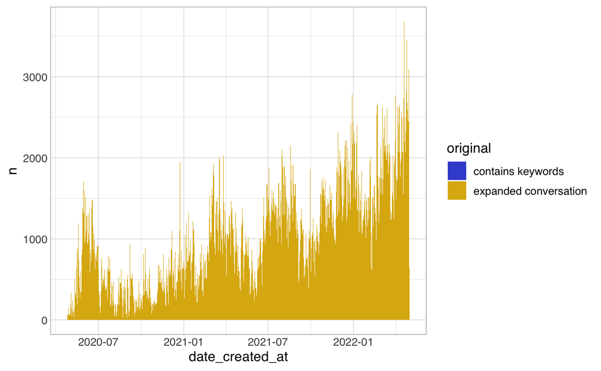

```r
tweets_c %>%
  filter(ur_conversation_id==sql("1254210334241419264")) %>%
  count(original,date_created_at) %>%
  collect() %>%
  mutate(original=if_else(original==1,"contains keywords","expanded conversation")) %>%
  ggplot(aes(x=date_created_at,y=n,fill=original)) +
  geom_col(width=1,position = 'stack') +
  theme_hsci_discrete()
```

### Top hashtags per year

```r
tweets_c %>%
  filter(ur_conversation_id==sql("1254210334241419264")) %>%
  left_join(tweet_hashtags_c,by=c("tweet_id")) %>%
  count(hashtag,year_created_at) %>%
  group_by(year_created_at) %>%
  slice_max(n,n=10) %>%
  gt(groupname_col="year_created_at",rowname_col="hashtag")
```

|  | n |
| --- | --- |
| 2020 |  |
| NA | 120958 |
| ruinables | 157 |
| ClimateChange | 156 |
| ClimateCult | 107 |
| ClimateBrawl | 103 |
| ClimateHoax | 98 |
| climatecrisis | 88 |
| INSTABLOCK | 38 |
| ClimateHysterians | 31 |
| cathynewman | 24 |
| 2021 |  |
| NA | 403639 |
| climatechange | 778 |
| climatebrawl | 705 |
| ClimateCrisis | 471 |
| Hypocrite | 235 |
| FakeGreen | 222 |
| ClimateHysterians | 173 |
| NeVautRien | 165 |
| PayYourBet | 144 |
| hypocrites | 131 |
| ClimateCult | 131 |
| 2022 |  |
| NA | 217117 |
| climatechange | 1120 |
| climatebrawl | 900 |
| CLIMATECULT | 882 |
| ClimateCrisis | 789 |
| CLIMATEHOAX | 767 |
| ClimateEmergency | 743 |
| coward | 463 |
| PayYourBet | 449 |
| GoldFishBenny | 183 |

## Conversation 647567168167636992: the erotic fiction

```r
tweets_c_i %>%
  filter(ur_conversation_id==sql("647567168167636992")) %>%
  summarize(
    tweets=n(),
    tweets_with_keywords=sum(original),
    authors=n_distinct(author_id),
    min_date=min(created_at),
    max_date=max(created_at)
  ) %>% collect() %>%
  bind_cols(
    tweets_c_i %>%
      filter(ur_conversation_id==sql("647567168167636992")) %>%
      count(author_id,name="tweets_per_author") %>%
      mutate(m_t_p_a=mean(tweets_per_author)) %>%
      summarize(mean_tweets_per_author=mean(tweets_per_author),tweets_per_author_mean_absolute_deviation=mean(abs(m_t_p_a-tweets_per_author))) %>% collect()
  ) %>%
  gt()
```

| tweets | tweets_with_keywords | authors | min_date | max_date | mean_tweets_per_author | tweets_per_author_mean_absolute_deviation |
| --- | --- | --- | --- | --- | --- | --- |
| 129905 | 2 | 10 | 2015-09-26 00:23:03 | 2022-05-01 20:51:03 | 12990.5 | 20783.2 |

### First 20 tweets

```r
tweets_c_i %>%
  filter(ur_conversation_id==sql("647567168167636992")) %>%
  left_join(users_c_i,by=c("author_id"="user_id")) %>%
  arrange(created_at.x) %>%
  head(20) %>%
  mutate(tweet_id=str_c("[",tweet_id,"](https://twitter.com/a/status/",tweet_id,")")) %>%
  mutate(conversation_id=str_c("[",conversation_id,"](https://twitter.com/a/status/",conversation_id,")")) %>%
  mutate(ur_conversation_id=str_c("[",ur_conversation_id,"](https://twitter.com/a/status/",ur_conversation_id,")")) %>%
  gt() %>%
  fmt_markdown(tweet_id|conversation_id|ur_conversation_id)
```

| tweet_id | ur_conversation_id | conversation_id | author_id | created_at.x | retweet_count | reply_count | like_count | quote_count | lang | text | in_reply_to | in_reply_to_user_id | quotes | retweet_of | error.x | error_detail.x | original | hashtags | urls | mentions | children | ur_children | descendants | ur_descendants | leaf_descendants | ur_leaf_descendants | max_depth | ur_max_depth | t_authors | … |
| --- | --- | --- | --- | --- | --- | --- | --- | --- | --- | --- | --- | --- | --- | --- | --- | --- | --- | --- | --- | --- | --- | --- | --- | --- | --- | --- | --- | --- | --- | --- |
| 647567168167636992 | 647567168167636992 | 647567168167636992 | 3043468000 | 2015-09-26 00:23:03 | 0 | 1 | 0 | 0 | en | "Jamesy?..." | NA | NA | NA | NA | NA | NA | 0 | NA | NA | NA | 1 | 1 | 129714 | 129714 | 2950 | 2950 | 54817 | 54817 | 10 | … |
| 647568089085800448 | 647567168167636992 | 647567168167636992 | 1037950304 | 2015-09-26 00:27:01 | 0 | 1 | 0 | 0 | en | @HisProtegee Yeah? | 647567168167636992 | 3043468000 | NA | NA | NA | NA | 0 | NA | NA | 1 | 1 | 1 | 129713 | 129713 | 2950 | 2950 | 54816 | 54816 | 10 | … |
| 647569072771760130 | 647567168167636992 | 647567168167636992 | 3043468000 | 2015-09-26 00:31:01 | 0 | 1 | 0 | 0 | en | @JamesYourKing "I need a cuddle..." | 647568089085800448 | 1037950304 | NA | NA | NA | NA | 0 | NA | NA | 1 | 1 | 1 | 129712 | 129712 | 2950 | 2950 | 54815 | 54815 | 10 | … |
| 647569290619691008 | 647567168167636992 | 647567168167636992 | 1037950304 | 2015-09-26 00:32:00 | 0 | 1 | 0 | 0 | en | @HisProtegee /Just/ a cuddle? | 647569072771760130 | 3043468000 | NA | NA | NA | NA | 0 | NA | NA | 1 | 1 | 1 | 129711 | 129711 | 2950 | 2950 | 54814 | 54814 | 10 | … |
| 647569636356177920 | 647567168167636992 | 647567168167636992 | 3043468000 | 2015-09-26 00:33:02 | 0 | 1 | 0 | 0 | en | @JamesYourKing "I...yeah. Is that okay? I just need you to hold me right now..." | 647569290619691008 | 1037950304 | NA | NA | NA | NA | 0 | NA | NA | 1 | 1 | 1 | 129710 | 129710 | 2950 | 2950 | 54813 | 54813 | 10 | … |
| 647570247478870016 | 647567168167636992 | 647567168167636992 | 1037950304 | 2015-09-26 00:35:05 | 0 | 1 | 0 | 0 | en | @HisProtegee Yeah.. My lap is free? *He winks at her* Feel free.. Come and cuddle me up.. | 647569636356177920 | 3043468000 | NA | NA | NA | NA | 0 | NA | NA | 1 | 1 | 1 | 129709 | 129709 | 2950 | 2950 | 54812 | 54812 | 10 | … |
| 647570534180462592 | 647567168167636992 | 647567168167636992 | 3043468000 | 2015-09-26 00:37:00 | 0 | 1 | 0 | 0 | en | @JamesYourKing She smiles softly and sits down on his lap, curling up against him as her arms wrap around him and she presses her face - | 647570247478870016 | 1037950304 | NA | NA | NA | NA | 0 | NA | NA | 1 | 1 | 1 | 129708 | 129708 | 2950 | 2950 | 54811 | 54811 | 10 | … |
| 647570595333414912 | 647567168167636992 | 647567168167636992 | 3043468000 | 2015-09-26 00:37:01 | 0 | 1 | 0 | 0 | en | @JamesYourKing -against his chest, letting out a shaky sigh. | 647570534180462592 | 3043468000 | NA | NA | NA | NA | 0 | NA | NA | 1 | 1 | 1 | 129707 | 129707 | 2950 | 2950 | 54810 | 54810 | 10 | … |
| 647571274328342528 | 647567168167636992 | 647567168167636992 | 1037950304 | 2015-09-26 00:39:05 | 0 | 1 | 0 | 0 | en | @HisProtegee So what's the matter, babe? *He kisses her cheek and smiles softly* Something you want to tell me? | 647570595333414912 | 3043468000 | NA | NA | NA | NA | 0 | NA | NA | 1 | 1 | 1 | 129706 | 129706 | 2950 | 2950 | 54809 | 54809 | 10 | … |
| 647572174094663680 | 647567168167636992 | 647567168167636992 | 3043468000 | 2015-09-26 00:43:03 | 0 | 1 | 0 | 0 | en | @JamesYourKing "No...I just...I need a hug." She says in a high pitched voice as tears start filling her eyes. | 647571274328342528 | 1037950304 | NA | NA | NA | NA | 0 | NA | NA | 1 | 1 | 1 | 129705 | 129705 | 2950 | 2950 | 54808 | 54808 | 10 | … |
| 647572408564625408 | 647567168167636992 | 647567168167636992 | 1037950304 | 2015-09-26 00:44:02 | 0 | 1 | 0 | 0 | en | @HisProtegee Why..? What's wrong. If you think I can't tell when you're upset by now.. Then you're the stupid one. | 647572174094663680 | 3043468000 | NA | NA | NA | NA | 0 | NA | NA | 1 | 1 | 1 | 129704 | 129704 | 2950 | 2950 | 54807 | 54807 | 10 | … |
| 647573122686676992 | 647567168167636992 | 647567168167636992 | 3043468000 | 2015-09-26 00:47:01 | 0 | 1 | 0 | 0 | en | @JamesYourKing "I honestly don't know...but I've been feeling like shit lately...could be my stupid period." She snorts. | 647572408564625408 | 1037950304 | NA | NA | NA | NA | 0 | NA | NA | 1 | 1 | 1 | 129703 | 129703 | 2950 | 2950 | 54806 | 54806 | 10 | … |
| 647697480453386240 | 647567168167636992 | 647567168167636992 | 1037950304 | 2015-09-26 09:01:02 | 0 | 1 | 0 | 0 | en | @HisProtegee Yeah... Are you on now? *He strokes her thighs* You don't feel too good do you? | 647573122686676992 | 3043468000 | NA | NA | NA | NA | 0 | NA | NA | 1 | 1 | 1 | 129702 | 129702 | 2950 | 2950 | 54805 | 54805 | 10 | … |
| 647717903320543232 | 647567168167636992 | 647567168167636992 | 3043468000 | 2015-09-26 10:22:03 | 0 | 1 | 0 | 0 | en | @JamesYourKing "Yeah...I am...and my tummy hurts and all I want to do is stay in bed all day..." she murmurs. "Sorry..." she sighs. | 647697480453386240 | 1037950304 | NA | NA | NA | NA | 0 | NA | NA | 1 | 1 | 1 | 129701 | 129701 | 2950 | 2950 | 54804 | 54804 | 10 | … |
| 647722433504538624 | 647567168167636992 | 647567168167636992 | 1037950304 | 2015-09-26 10:40:03 | 0 | 1 | 0 | 0 | en | @HisProtegee Don't be sorry, beautiful... *He strokes her hair and kisses her cheek* I love you to bits... I love you so much.. | 647717903320543232 | 3043468000 | NA | NA | NA | NA | 0 | NA | NA | 1 | 1 | 1 | 129700 | 129700 | 2950 | 2950 | 54803 | 54803 | 10 | … |
| 647722860413386752 | 647567168167636992 | 647567168167636992 | 3043468000 | 2015-09-26 10:42:01 | 0 | 2 | 0 | 0 | en | @JamesYourKing "I love you too..." she whispers, moving her head to lean up and peck his lips. | 647722433504538624 | 1037950304 | NA | NA | NA | NA | 0 | NA | NA | 1 | 2 | 2 | 129699 | 129699 | 2950 | 2950 | 54802 | 54802 | 10 | … |
| 647723375381622784 | 647567168167636992 | 647567168167636992 | 1037950304 | 2015-09-26 10:44:02 | 0 | 0 | 0 | 0 | en | @HisProtegee *He looks up at her and pulls her in for a close cuddle* Tell you what, you go and get some blankets and I'll make it up - | 647722860413386752 | 3043468000 | NA | NA | NA | NA | 0 | NA | NA | 1 | 0 | 0 | 0 | 0 | 0 | 0 | 0 | 0 | 1 | … |
| 647723463545896960 | 647567168167636992 | 647567168167636992 | 1037950304 | 2015-09-26 10:44:04 | 0 | 1 | 0 | 0 | en | @HisProtegee -nice and cosy.. and get you a hot water bottle.. We'll have a movie day okay?.. | 647722860413386752 | 3043468000 | NA | NA | NA | NA | 0 | NA | NA | 1 | 1 | 1 | 129697 | 129697 | 2949 | 2949 | 54801 | 54801 | 10 | … |
| 647723903566127104 | 647567168167636992 | 647567168167636992 | 3043468000 | 2015-09-26 10:46:02 | 0 | 1 | 0 | 0 | en | @JamesYourKing Her lips curl up into a smile as she nods excitedly. "Yeah...that sounds perfect, baby...thank you so much..That's exactly - | 647723463545896960 | 1037950304 | NA | NA | NA | NA | 0 | NA | NA | 1 | 1 | 1 | 129696 | 129696 | 2949 | 2949 | 54800 | 54800 | 10 | … |
| 647723976261812224 | 647567168167636992 | 647567168167636992 | 3043468000 | 2015-09-26 10:46:04 | 0 | 1 | 0 | 0 | en | @JamesYourKing -what I need right now." | 647723903566127104 | 3043468000 | NA | NA | NA | NA | 0 | NA | NA | 1 | 1 | 1 | 129695 | 129695 | 2949 | 2949 | 54799 | 54799 | 10 | … |

### Random 20 tweets

```r
tweets_c_i %>%
  filter(ur_conversation_id==sql("647567168167636992")) %>%
  arrange(sql("RAND()")) %>%
  head(20) %>%
  arrange(created_at) %>%
  left_join(users_c_i,by=c("author_id"="user_id")) %>%
  mutate(tweet_id=str_c("[",tweet_id,"](https://twitter.com/a/status/",tweet_id,")")) %>%
  mutate(conversation_id=str_c("[",conversation_id,"](https://twitter.com/a/status/",conversation_id,")")) %>%
  mutate(ur_conversation_id=str_c("[",ur_conversation_id,"](https://twitter.com/a/status/",ur_conversation_id,")")) %>%
  gt() %>%
  fmt_markdown(tweet_id|conversation_id|ur_conversation_id)
```

| tweet_id | ur_conversation_id | conversation_id | author_id | created_at.x | retweet_count | reply_count | like_count | quote_count | lang | text | in_reply_to | in_reply_to_user_id | quotes | retweet_of | error.x | error_detail.x | original | hashtags | urls | mentions | children | ur_children | descendants | ur_descendants | leaf_descendants | ur_leaf_descendants | max_depth | ur_max_depth | t_authors | … |
| --- | --- | --- | --- | --- | --- | --- | --- | --- | --- | --- | --- | --- | --- | --- | --- | --- | --- | --- | --- | --- | --- | --- | --- | --- | --- | --- | --- | --- | --- | --- |
| 1520868562616958976 | 647567168167636992 | 647567168167636992 | 1037950304 | 2022-05-01 20:51:03 | 0 | 0 | 0 | 0 | en | @HisProtegee -Taking a minute step forward, he presses his clothed length against her folds and catches her lips in another hard kiss, sucking her lip between his teeth to bite her there. "Jesus.. I c… | 1520868258089521155 | 1037950304 | NA | NA | NA | NA | 0 | NA | NA | 1 | 0 | 0 | 0 | 0 | 0 | 0 | 0 | 0 | 1 | … |
| 1519074913331687428 | 647567168167636992 | 647567168167636992 | 1037950304 | 2022-04-26 22:04:01 | 0 | 1 | 0 | 0 | en | @HisProtegee "See you soon, babies.." He nods, coming over to kiss Natalie's lips slowly and gently, cupping her cheek before stepping back. "Okay, see you later sweetheart.." Giving her a wink, he go… | 1518574185756471300 | 3043468000 | NA | NA | NA | NA | 0 | NA | NA | 1 | 1 | 1 | 6 | 6 | 1 | 1 | 6 | 6 | 2 | … |
| 1520868258089521155 | 647567168167636992 | 647567168167636992 | 1037950304 | 2022-05-01 20:50:02 | 0 | 1 | 0 | 0 | en | @HisProtegee Breathing hard and fast against her lips in anticipation, he lingers on her lips with his eyes taking in every detail of her features and her darkened eyes. His lips curl up to reveal a t… | 1520371443699265537 | 3043468000 | NA | NA | NA | NA | 0 | NA | NA | 1 | 1 | 1 | 1 | 1 | 1 | 1 | 1 | 1 | 1 | … |
| 1520867766546358272 | 647567168167636992 | 647567168167636992 | 1037950304 | 2022-05-01 20:48:02 | 0 | 0 | 0 | 0 | en | @HisProtegee -to perch beside her by the doorway, obviously tired from the kids already. | 1520867669540585473 | 1037950304 | NA | NA | NA | NA | 0 | NA | NA | 1 | 0 | 0 | 0 | 0 | 0 | 0 | 0 | 0 | 1 | … |
| 1520867669540585473 | 647567168167636992 | 647567168167636992 | 1037950304 | 2022-05-01 20:48:00 | 0 | 1 | 0 | 0 | en | @HisProtegee The kids follow Leo with beaming laughs, fussing him and picking up their favourite toys to run around the garden and play. It was turning out to be quite a nice morning with the sun peek… | 1520374809967931392 | 3043468000 | NA | NA | NA | NA | 0 | NA | NA | 1 | 1 | 1 | 1 | 1 | 1 | 1 | 1 | 1 | 1 | … |
| 1520867268581810178 | 647567168167636992 | 647567168167636992 | 1037950304 | 2022-05-01 20:46:02 | 0 | 0 | 0 | 0 | en | @HisProtegee -only to tease her for now, using his free hand to spread her legs as his length presses to her heat. "Jesus.." | 1520867142992039936 | 1037950304 | NA | NA | NA | NA | 0 | NA | NA | 1 | 0 | 0 | 0 | 0 | 0 | 0 | 0 | 0 | 1 | … |
| 1520867142992039936 | 647567168167636992 | 647567168167636992 | 1037950304 | 2022-05-01 20:45:05 | 0 | 1 | 0 | 0 | en | @HisProtegee Feeling his trousers tighter at that, he reaches forward with a clenched jaw to grip her hair in a makeshift ponytail to bring her head up and back towards him. "Fuck.." He whispers out, … | 1520533180226359302 | 3043468000 | NA | NA | NA | NA | 0 | NA | NA | 1 | 1 | 1 | 1 | 1 | 1 | 1 | 1 | 1 | 1 | … |
| 1520171447964123136 | 647567168167636992 | 647567168167636992 | 1037950304 | 2022-04-29 22:41:03 | 0 | 1 | 0 | 0 | en | @HisProtegee -to push her down onto the hard surface on her chest. "Fuck.. You're so hot.." He whispers out, looking into her eyes through the tall mirror in front of them, pulling down her trousers a… | 1520171059324108801 | 1037950304 | NA | NA | NA | NA | 0 | NA | NA | 1 | 1 | 1 | 4 | 4 | 1 | 1 | 4 | 4 | 2 | … |
| 1520171059324108801 | 647567168167636992 | 647567168167636992 | 1037950304 | 2022-04-29 22:39:05 | 0 | 1 | 0 | 0 | en | @HisProtegee "Yeah?.." He moans out, looking back and down at the door before shoving his work bag against it to act as a barricade. Letting out a breathy whimper at her touch on him, he moves both ha… | 1518338518996631555 | 3043468000 | NA | NA | NA | NA | 0 | NA | NA | 1 | 1 | 1 | 5 | 5 | 1 | 1 | 5 | 5 | 2 | … |
| 1520170415712309256 | 647567168167636992 | 647567168167636992 | 1037950304 | 2022-04-29 22:37:02 | 0 | 1 | 0 | 0 | en | @HisProtegee The kids both turn their attention to Natalie and cheer, slipping down from their chairs to run over to the french doors. Leo, woken by the noise, excitedly runs to the doors with the kid… | 1520160287738970112 | 3043468000 | NA | NA | NA | NA | 0 | NA | NA | 1 | 1 | 1 | 3 | 3 | 1 | 1 | 3 | 3 | 2 | … |
| 1519076148096995329 | 647567168167636992 | 647567168167636992 | 1037950304 | 2022-04-26 22:09:01 | 0 | 1 | 0 | 0 | en | @HisProtegee "Fuck.. that makes it even hotter." He snorts, leaning in to kiss her hard as she begins to unbuckle his belt. Looking between them with a breathy moan, he helps her push down his trouser… | 1518353213229092864 | 3043468000 | NA | NA | NA | NA | 0 | NA | NA | 1 | 1 | 1 | 3 | 3 | 1 | 1 | 3 | 3 | 2 | … |
| 1487931939692720136 | 647567168167636992 | 647567168167636992 | 1037950304 | 2022-01-30 23:33:01 | 0 | 1 | 0 | 0 | en | @HisProtegee "Yeah.. True." He didn't want to explain how advanced Amelia was just in case Justin took offence to that comparison to their kids' intelligence. He finishes off the last of his whisky be… | 1487931115570671616 | 3043468000 | NA | NA | NA | NA | 1 | NA | NA | 1 | 1 | 1 | 342 | 342 | 2 | 2 | 341 | 341 | 2 | … |
| 1487931115570671616 | 647567168167636992 | 647567168167636992 | 3043468000 | 2022-01-30 23:29:05 | 0 | 1 | 0 | 0 | en | @JamesYourKing J:”It’s all good, really… I know how fathers are with their daughters.” He says with a chuckle. J:”They’re still kids, anyway. I doubt they’ll know what heartache is before they’re teen… | 1487925903791468553 | 1037950304 | NA | NA | NA | NA | 1 | NA | NA | 1 | 1 | 1 | 343 | 343 | 2 | 2 | 342 | 342 | 2 | … |
| 1518574185756471300 | 647567168167636992 | 647567168167636992 | 3043468000 | 2022-04-25 12:54:03 | 0 | 1 | 0 | 0 | en | @JamesYourKing Amelia smiles up at him, nodding as she hops off her chair then. A:”Okay… Bye, Daddy.” She says softly, Natalie stroking over her daughter’s hair as she comes over to stand next to her.… | 1518517231788904448 | 1037950304 | NA | NA | NA | NA | 0 | NA | NA | 1 | 1 | 1 | 7 | 7 | 1 | 1 | 7 | 7 | 2 | … |
| 1520160176057331715 | 647567168167636992 | 647567168167636992 | 3043468000 | 2022-04-29 21:56:04 | 0 | 1 | 0 | 0 | en | @JamesYourKing She lingers on his lips for a few seconds, reluctantly letting him go but still putting on a smile to make it easier for him. “See you later, love…” she says, sighing softly when he clo… | 1519074913331687428 | 1037950304 | NA | NA | NA | NA | 0 | NA | NA | 1 | 1 | 1 | 5 | 5 | 1 | 1 | 5 | 5 | 2 | … |
| 1520160287738970112 | 647567168167636992 | 647567168167636992 | 3043468000 | 2022-04-29 21:57:01 | 0 | 1 | 0 | 0 | en | @JamesYourKing - missing a beat, determined to keep the kids entertained while he’d be away. | 1520160176057331715 | 3043468000 | NA | NA | NA | NA | 0 | NA | NA | 1 | 1 | 1 | 4 | 4 | 1 | 1 | 4 | 4 | 2 | … |
| 1520371443699265537 | 647567168167636992 | 647567168167636992 | 3043468000 | 2022-04-30 11:56:01 | 0 | 1 | 0 | 0 | en | @JamesYourKing She helps him pull her dress up, her womanhood being exposed to him quite easily as she spreads her legs for him with a knowing smirk. “Yeah?… How badly do you want me, baby?” She asks … | 1519076148096995329 | 1037950304 | NA | NA | NA | NA | 0 | NA | NA | 1 | 1 | 1 | 2 | 2 | 1 | 1 | 2 | 2 | 2 | … |
| 1520374809967931392 | 647567168167636992 | 647567168167636992 | 3043468000 | 2022-04-30 12:09:03 | 0 | 1 | 0 | 0 | en | @JamesYourKing “Okay, okay! I’m coming!” She laughs, shaking her head as she rushes over to open the doors and let them all out into the garden. Sighing softly, she runs her fingers through her hair a… | 1520170415712309256 | 1037950304 | NA | NA | NA | NA | 0 | NA | NA | 1 | 1 | 1 | 2 | 2 | 1 | 1 | 2 | 2 | 2 | … |
| 1520532887505981441 | 647567168167636992 | 647567168167636992 | 3043468000 | 2022-04-30 22:37:04 | 0 | 1 | 0 | 0 | en | @JamesYourKing Natalie lets him walk her over to the dresser, pleasantly surprised at his swift moves as he pushes her down against the furniture. Her gaze is locked on his own through the mirror, her… | 1520171447964123136 | 1037950304 | NA | NA | NA | NA | 0 | NA | NA | 1 | 1 | 1 | 3 | 3 | 1 | 1 | 3 | 3 | 2 | … |
| 1520533180226359302 | 647567168167636992 | 647567168167636992 | 3043468000 | 2022-04-30 22:38:05 | 0 | 1 | 0 | 0 | en | @JamesYourKing - big cock inside me…” she says in a small whine, arching her back as she gets settled in front of him. | 1520532887505981441 | 3043468000 | NA | NA | NA | NA | 0 | NA | NA | 1 | 1 | 1 | 2 | 2 | 1 | 1 | 2 | 2 | 2 | … |

### Temporal extent

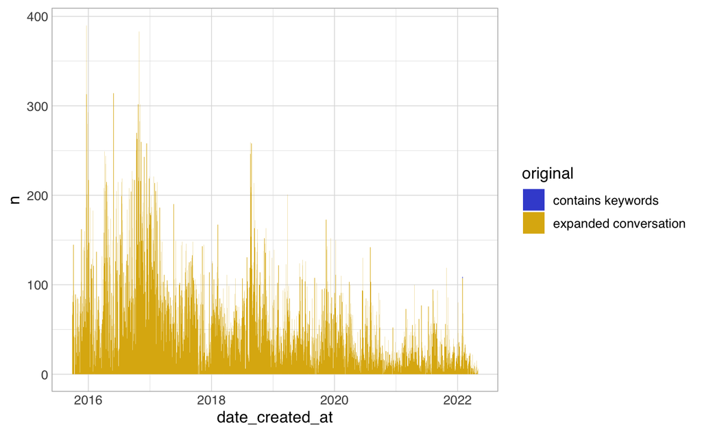

```r
tweets_c %>%
  filter(ur_conversation_id==sql("647567168167636992")) %>%
  count(original,date_created_at) %>%
  collect() %>%
  mutate(original=if_else(original==1,"contains keywords","expanded conversation")) %>%
  ggplot(aes(x=date_created_at,y=n,fill=original)) +
  geom_col(width=1,position = 'stack') +
  theme_hsci_discrete()
```

### Top hashtags per year

```r
tweets_c %>%
  filter(ur_conversation_id==sql("647567168167636992")) %>%
  left_join(tweet_hashtags_c,by=c("tweet_id")) %>%
  count(hashtag,year_created_at) %>%
  group_by(year_created_at) %>%
  slice_max(n,n=10) %>%
  gt(groupname_col="year_created_at",rowname_col="hashtag")
```

|  | n |
| --- | --- |
| 2015 |  |
| NA | 7264 |
| TimeSkip | 1 |
| 2016 |  |
| NA | 36153 |
| TimeSkip | 4 |
| TS | 1 |
| thanks | 1 |
| 2017 |  |
| NA | 26135 |
| TimeSkip | 3 |
| 2018 |  |
| NA | 23357 |
| 2019 |  |
| NA | 15447 |
| Timeskip | 2 |
| 2020 |  |
| NA | 11651 |
| Timeskip | 1 |
| 2021 |  |
| NA | 8127 |
| 2022 |  |
| NA | 1758 |

## Conversation 1488162322187182085: Trudeau tests positive for COVID-19

```r
tweets_c_i %>%
  filter(ur_conversation_id==sql("1488162322187182085")) %>%
  summarize(
    tweets=n(),
    tweets_with_keywords=sum(original),
    authors=n_distinct(author_id),
    min_date=min(created_at),
    max_date=max(created_at)
  ) %>% collect() %>%
  bind_cols(
    tweets_c_i %>%
      filter(ur_conversation_id==sql("1488162322187182085")) %>%
      count(author_id,name="tweets_per_author") %>%
      mutate(m_t_p_a=mean(tweets_per_author)) %>%
      summarize(mean_tweets_per_author=mean(tweets_per_author),tweets_per_author_mean_absolute_deviation=mean(abs(m_t_p_a-tweets_per_author))) %>% collect()
  ) %>%
  gt()
```

| tweets | tweets_with_keywords | authors | min_date | max_date | mean_tweets_per_author | tweets_per_author_mean_absolute_deviation |
| --- | --- | --- | --- | --- | --- | --- |
| 67226 | 3489 | 42641 | 2022-01-31 14:48:04 | 2022-04-28 13:47:02 | 1.5766 | 0.8766309 |

### First 20 tweets

```r
tweets_c_i %>%
  filter(ur_conversation_id==sql("1488162322187182085")) %>%
  left_join(users_c_i,by=c("author_id"="user_id")) %>%
  arrange(created_at.x) %>%
  head(20) %>%
  mutate(tweet_id=str_c("[",tweet_id,"](https://twitter.com/a/status/",tweet_id,")")) %>%
  mutate(conversation_id=str_c("[",conversation_id,"](https://twitter.com/a/status/",conversation_id,")")) %>%
  mutate(ur_conversation_id=str_c("[",ur_conversation_id,"](https://twitter.com/a/status/",ur_conversation_id,")")) %>%
  gt() %>%
  fmt_markdown(tweet_id|conversation_id|ur_conversation_id)
```

| tweet_id | ur_conversation_id | conversation_id | author_id | created_at.x | retweet_count | reply_count | like_count | quote_count | lang | text | in_reply_to | in_reply_to_user_id | quotes | retweet_of | error.x | error_detail.x | original | hashtags | urls | mentions | children | ur_children | descendants | ur_descendants | leaf_descendants | ur_leaf_descendants | max_depth | ur_max_depth | t_authors | … |
| --- | --- | --- | --- | --- | --- | --- | --- | --- | --- | --- | --- | --- | --- | --- | --- | --- | --- | --- | --- | --- | --- | --- | --- | --- | --- | --- | --- | --- | --- | --- |
| 1488162322187182085 | 1488162322187182085 | 1488162322187182085 | 14260960 | 2022-01-31 14:48:04 | 4671 | 39013 | 35731 | 8296 | en | This morning, I tested positive for COVID-19. I’m feeling fine – and I’ll continue to work remotely this week while following public health guidelines. Everyone, please get vaccinated and get boosted. | NA | NA | NA | NA | NA | NA | 1 | NA | NA | NA | 34891 | 35423 | 58033 | 62325 | 53241 | 56789 | 37 | 37 | 39405 | … |
| 1488162389761703937 | 1488162322187182085 | 1488162322187182085 | 1467526165657264135 | 2022-01-31 14:48:05 | 0 | 0 | 0 | 0 | und | @JustinTrudeau Eat 💩💩💩💩💩 | 1488162322187182085 | 14260960 | NA | NA | NA | NA | 0 | NA | NA | 1 | 0 | 0 | 0 | 0 | 0 | 0 | 0 | 0 | 1 | … |
| 1488162383080132611 | 1488162322187182085 | 1488162322187182085 | 1484254352567160842 | 2022-01-31 14:48:05 | 0 | 0 | 0 | 0 | en | @JustinTrudeau Pussy | 1488162322187182085 | 14260960 | NA | NA | NA | NA | 0 | NA | NA | 1 | 0 | 0 | 0 | 0 | 0 | 0 | 0 | 0 | 1 | … |
| 1488162442714693637 | 1488162322187182085 | 1488162322187182085 | 29086857 | 2022-01-31 14:49:00 | 7 | 4 | 460 | 0 | en | @JustinTrudeau Thank God your triple vaxxed can we get on with our lives please? | 1488162322187182085 | 14260960 | NA | NA | NA | NA | 0 | NA | NA | 1 | 3 | 3 | 14 | 14 | 7 | 7 | 7 | 7 | 10 | … |
| 1488162436930752514 | 1488162322187182085 | 1488162322187182085 | 1485333562199101446 | 2022-01-31 14:49:00 | 0 | 1 | 10 | 0 | en | @JustinTrudeau Who you calling racist? https://twitter.com/pipelinebandit/status/1488162436930752514/photo/1 | 1488162322187182085 | 14260960 | NA | NA | NA | NA | 0 | NA | 1 | 1 | 1 | 1 | 1 | 1 | 1 | 1 | 1 | 1 | 2 | … |
| 1488162418295382017 | 1488162322187182085 | 1488162322187182085 | 1478777799540297730 | 2022-01-31 14:49:00 | 0 | 0 | 0 | 0 | en | @JustinTrudeau Did you also test positive for being a bitch? | 1488162322187182085 | 14260960 | NA | NA | NA | NA | 0 | NA | NA | 1 | 0 | 0 | 0 | 0 | 0 | 0 | 0 | 0 | 1 | … |
| 1488162465145835530 | 1488162322187182085 | 1488162322187182085 | 119911112 | 2022-01-31 14:49:01 | 0 | 32 | 23 | 1 | en | @JustinTrudeau Wishing you a swift recovery. | 1488162322187182085 | 14260960 | NA | NA | NA | NA | 0 | NA | NA | 1 | 28 | 28 | 29 | 29 | 28 | 28 | 2 | 2 | 29 | … |
| 1488162460636880900 | 1488162322187182085 | 1488162322187182085 | 1166799437730963456 | 2022-01-31 14:49:01 | 2 | 2 | 204 | 0 | und | @JustinTrudeau https://twitter.com/jackravager/status/1488162460636880900/photo/1 | 1488162322187182085 | 14260960 | NA | NA | NA | NA | 0 | NA | 1 | 1 | 2 | 2 | 2 | 2 | 2 | 2 | 1 | 1 | 2 | … |
| 1488162449094287360 | 1488162322187182085 | 1488162322187182085 | 462566772 | 2022-01-31 14:49:01 | 25 | 43 | 837 | 2 | en | @JustinTrudeau Boosted and still testing positive 😂😂 | 1488162322187182085 | 14260960 | NA | NA | NA | NA | 0 | NA | NA | 1 | 42 | 42 | 181 | 181 | 121 | 121 | 15 | 15 | 118 | … |
| 1488162464944566275 | 1488162322187182085 | 1488162322187182085 | 1488086512801660932 | 2022-01-31 14:49:01 | 0 | 13 | 15 | 0 | en | @JustinTrudeau Get better soon! | 1488162322187182085 | 14260960 | NA | NA | NA | NA | 0 | NA | NA | 1 | 10 | 10 | 11 | 11 | 10 | 10 | 2 | 2 | 12 | … |
| 1488162468056612864 | 1488162322187182085 | 1488162322187182085 | 2448438361 | 2022-01-31 14:49:01 | 4 | 2 | 38 | 0 | ht | @JustinTrudeau Stay safe PMJT. 🙏🙏 | 1488162322187182085 | 14260960 | NA | NA | NA | NA | 0 | NA | NA | 1 | 2 | 2 | 2 | 2 | 2 | 2 | 1 | 1 | 3 | … |
| 1488162510976991233 | 1488162322187182085 | 1488162322187182085 | 3103615656 | 2022-01-31 14:49:02 | 2 | 87 | 80 | 2 | en | @JustinTrudeau Take care of yourself PM. Hope it passes quickly. | 1488162322187182085 | 14260960 | NA | NA | NA | NA | 0 | NA | NA | 1 | 65 | 65 | 94 | 94 | 83 | 83 | 8 | 8 | 82 | … |
| 1488162506619199490 | 1488162322187182085 | 1488162322187182085 | 2975434728 | 2022-01-31 14:49:02 | 0 | 0 | 3 | 0 | und | @JustinTrudeau @CameronAhmad #liar #CowardOfTheCottage | 1488162322187182085 | 14260960 | NA | NA | NA | NA | 0 | 2 | NA | 2 | 0 | 0 | 0 | 0 | 0 | 0 | 0 | 0 | 1 | … |
| 1488162510184271878 | 1488162322187182085 | 1488162322187182085 | 1364235529466892290 | 2022-01-31 14:49:02 | 0 | 0 | 0 | 0 | und | @JustinTrudeau https://twitter.com/DontCareAboutAF/status/1488162510184271878/photo/1 | 1488162322187182085 | 14260960 | NA | NA | NA | NA | 0 | NA | 1 | 1 | 0 | 0 | 0 | 0 | 0 | 0 | 0 | 0 | 1 | … |
| 1488162522297520129 | 1488162322187182085 | 1488162322187182085 | 804864943556333568 | 2022-01-31 14:49:02 | 0 | 2 | 0 | 0 | en | @JustinTrudeau Hopefully your not feeling so good that’s karma | 1488162322187182085 | 14260960 | NA | NA | NA | NA | 0 | NA | NA | 1 | 2 | 2 | 3 | 3 | 2 | 2 | 2 | 2 | 4 | … |
| 1488162499643985920 | 1488162322187182085 | 1488162322187182085 | 997719382502584320 | 2022-01-31 14:49:02 | 0 | 1 | 1 | 0 | en | @JustinTrudeau It’s the clown man https://twitter.com/TheHoboBaptist/status/1488162499643985920/photo/1 | 1488162322187182085 | 14260960 | NA | NA | NA | NA | 0 | NA | 1 | 1 | 1 | 1 | 4 | 4 | 1 | 1 | 4 | 4 | 2 | … |
| 1488162508330479618 | 1488162322187182085 | 1488162322187182085 | 1484254352567160842 | 2022-01-31 14:49:02 | 0 | 1 | 3 | 0 | und | @JustinTrudeau https://twitter.com/HodlAlabama/status/1488162508330479618/photo/1 | 1488162322187182085 | 14260960 | NA | NA | NA | NA | 0 | NA | 1 | 1 | 1 | 1 | 2 | 2 | 1 | 1 | 2 | 2 | 2 | … |
| 1488162496062136322 | 1488162322187182085 | 1488162322187182085 | 731889073829208064 | 2022-01-31 14:49:02 | 0 | 0 | 0 | 0 | en | @JustinTrudeau Get well soon Prime Minister | 1488162322187182085 | 14260960 | NA | NA | NA | NA | 1 | NA | NA | 1 | 0 | 0 | 0 | 0 | 0 | 0 | 0 | 0 | 1 | … |
| 1488162515355766785 | 1488162322187182085 | 1488162322187182085 | 1478777799540297730 | 2022-01-31 14:49:02 | 0 | 0 | 1 | 0 | en | @JustinTrudeau I’m good thanks No experimental gene therapy for me https://twitter.com/COVID____1984/status/1488162515355766785/photo/1 | 1488162322187182085 | 14260960 | NA | NA | NA | NA | 0 | NA | 1 | 1 | 0 | 0 | 0 | 0 | 0 | 0 | 0 | 0 | 1 | … |
| 1488162548251860995 | 1488162322187182085 | 1488162322187182085 | 204953155 | 2022-01-31 14:49:03 | 0 | 0 | 1 | 0 | en | @JustinTrudeau Get better soon! | 1488162322187182085 | 14260960 | NA | NA | NA | NA | 0 | NA | NA | 1 | 0 | 0 | 0 | 0 | 0 | 0 | 0 | 0 | 1 | … |

### Random 20 tweets

```r
tweets_c_i %>%
  filter(ur_conversation_id==sql("1488162322187182085")) %>%
  arrange(sql("RAND()")) %>%
  head(20) %>%
  arrange(created_at) %>%
  left_join(users_c_i,by=c("author_id"="user_id")) %>%
  mutate(tweet_id=str_c("[",tweet_id,"](https://twitter.com/a/status/",tweet_id,")")) %>%
  mutate(conversation_id=str_c("[",conversation_id,"](https://twitter.com/a/status/",conversation_id,")")) %>%
  mutate(ur_conversation_id=str_c("[",ur_conversation_id,"](https://twitter.com/a/status/",ur_conversation_id,")")) %>%
  gt() %>%
  fmt_markdown(tweet_id|conversation_id|ur_conversation_id)
```

| tweet_id | ur_conversation_id | conversation_id | author_id | created_at.x | retweet_count | reply_count | like_count | quote_count | lang | text | in_reply_to | in_reply_to_user_id | quotes | retweet_of | error.x | error_detail.x | original | hashtags | urls | mentions | children | ur_children | descendants | ur_descendants | leaf_descendants | ur_leaf_descendants | max_depth | ur_max_depth | t_authors | … |
| --- | --- | --- | --- | --- | --- | --- | --- | --- | --- | --- | --- | --- | --- | --- | --- | --- | --- | --- | --- | --- | --- | --- | --- | --- | --- | --- | --- | --- | --- | --- |
| 1488316041071497218 | 1488162322187182085 | 1488162322187182085 | 128745233 | 2022-02-01 00:59:03 | 52 | 11 | 240 | 14 | und | @drdavidsamadi @JustinTrudeau https://twitter.com/cschlaht/status/1488316041071497218/video/1 | 1488173337901740040 | 25816369 | NA | NA | NA | NA | 0 | NA | 1 | 2 | 10 | 10 | 10 | 10 | 10 | 10 | 1 | 1 | 11 | … |
| 1488203476123406338 | 1488162322187182085 | 1488198689331892226 | 1111290178616942593 | 2022-01-31 17:32:01 | 0 | 0 | 0 | 0 | en | @JaroGiesbrecht @JustinTrudeau Our household sends our best wishes and unwavering support to yours @JustinTrudeau❤️🇨🇦 We firmly stand with you in the face of this adversity. | 1488198689331892226 | 807787995940036608 | NA | NA | NA | NA | 0 | NA | NA | 3 | 0 | 0 | 0 | 0 | 0 | 0 | 0 | 0 | 1 | … |
| 1488218781373534208 | 1488162322187182085 | 1488203474223644675 | 347212392 | 2022-01-31 18:33:00 | 0 | 0 | 0 | 0 | tl | @Divya_Mudunuri Hehe | 1488204100638580737 | 2322966235 | NA | NA | NA | NA | 0 | NA | NA | 1 | 0 | 0 | 0 | 0 | 0 | 0 | 0 | 0 | 1 | … |
| 1489715994729893890 | 1488162322187182085 | 1488177757016276996 | 42226484 | 2022-02-04 21:42:02 | 0 | 0 | 0 | 0 | und | @MaximeBernier #maximebernierisuseless | 1488177757016276996 | 2791988124 | NA | NA | NA | NA | 0 | 1 | NA | 1 | 0 | 0 | 0 | 0 | 0 | 0 | 0 | 0 | 1 | … |
| 1488164152455663619 | 1488162322187182085 | 1488164152455663619 | 889578475 | 2022-01-31 14:55:05 | 0 | 0 | 1 | 1 | en | YOU should be making a public statement, condemning the actions of these racist protesters at the state capital, INCOMPETENCE leads to unrest You would be spewing your racist rule of law rhetoric had … | NA | NA | 1488162322187182085 | NA | NA | NA | 0 | NA | 1 | NA | 0 | 0 | 0 | 0 | 0 | 0 | 0 | 0 | 1 | … |
| 1489606484384268288 | 1488162322187182085 | 1488177757016276996 | 210151128 | 2022-02-04 14:27:01 | 0 | 1 | 1 | 0 | en | @CryptoSala @DebbieLucch @MaximeBernier How could they hide it, it’s certainly not happening in North America, but don’t let facts get in your way. | 1488427302539116545 | 1309290832223141888 | NA | NA | NA | NA | 0 | NA | NA | 3 | 1 | 1 | 1 | 1 | 1 | 1 | 1 | 1 | 2 | … |
| 1488204280846856192 | 1488162322187182085 | 1488202808792862724 | 789154394541584384 | 2022-01-31 17:35:02 | 0 | 0 | 0 | 0 | und | @NavinR30 😂😂😂 | 1488202808792862724 | 2959221285 | NA | NA | NA | NA | 0 | NA | NA | 1 | 0 | 0 | 0 | 0 | 0 | 0 | 0 | 0 | 1 | … |
| 1488176221540085763 | 1488162322187182085 | 1488176221540085763 | 1287156284215537664 | 2022-01-31 15:43:05 | 3 | 0 | 5 | 1 | en | Do I have to say it? Well I did a bit today on http://www.blackjestermatters.com #BigPharma #CDNPOli https://twitter.com/JustinTrudeau/status/1488162322187182085 | NA | NA | 1488162322187182085 | NA | NA | NA | 0 | 2 | 2 | NA | 0 | 0 | 0 | 0 | 0 | 0 | 0 | 0 | 1 | … |
| 1489599956239405062 | 1488162322187182085 | 1488177757016276996 | 1222341254 | 2022-02-04 14:01:01 | 0 | 0 | 0 | 0 | en | @thunderbolt5523 @MaximeBernier I’m not saying the vaccine doesn’t help fight the virus I’m sure it does . But lockdown mandates vax passports all wrong and against the law and the charter | 1489578381440126979 | 272626302 | NA | NA | NA | NA | 0 | NA | NA | 2 | 0 | 0 | 0 | 0 | 0 | 0 | 0 | 0 | 1 | … |
| 1489289377637359616 | 1488162322187182085 | 1488177757016276996 | 1222341254 | 2022-02-03 17:27:01 | 0 | 1 | 0 | 0 | en | @thunderbolt5523 @MaximeBernier Actually I got Covid stayed home took some medicine and rested and guess what I recovered go figure | 1489254450271162375 | 272626302 | NA | NA | NA | NA | 0 | NA | NA | 2 | 1 | 1 | 3 | 3 | 2 | 2 | 2 | 2 | 2 | … |
| 1489289639349399559 | 1488162322187182085 | 1488177757016276996 | 1222341254 | 2022-02-03 17:28:01 | 0 | 0 | 0 | 0 | en | @thunderbolt5523 @MaximeBernier Agree so band all fast food then ? No different then forced vaccines | 1489254868116140046 | 272626302 | NA | NA | NA | NA | 0 | NA | NA | 2 | 0 | 0 | 0 | 0 | 0 | 0 | 0 | 0 | 1 | … |
| 1489599541963808771 | 1488162322187182085 | 1488177757016276996 | 1222341254 | 2022-02-04 13:59:04 | 0 | 0 | 0 | 0 | en | @thunderbolt5523 @MaximeBernier Well that’s sad sorry to hear that . what other illnesses did they have ? And did they get help and treatment before it got bad ? Again can’t lockdown and mandate and v… | 1489578381440126979 | 272626302 | NA | NA | NA | NA | 0 | NA | NA | 2 | 0 | 0 | 0 | 0 | 0 | 0 | 0 | 0 | 1 | … |
| 1488402698693390337 | 1488162322187182085 | 1488400303409950722 | 1435467623714594818 | 2022-02-01 06:43:05 | 0 | 0 | 2 | 0 | et | @lady_of_law Karma is a bit*h, ab maza aayana Trudeau #TruckersForFreedom2022 | 1488400303409950722 | 1186237607950213120 | NA | NA | NA | NA | 0 | 1 | NA | NA | 0 | 0 | 0 | 0 | 0 | 0 | 0 | 0 | 1 | … |
| 1489578381440126979 | 1488162322187182085 | 1488177757016276996 | 272626302 | 2022-02-04 12:35:03 | 0 | 2 | 0 | 0 | en | @birddie9 @MaximeBernier Our cousin was not so fortunate Same story for 5 of our friends All prior to availability of vaccines | 1489289377637359616 | 1222341254 | NA | NA | NA | NA | 0 | NA | NA | 2 | 2 | 2 | 2 | 2 | 2 | 2 | 1 | 1 | 2 | … |
| 1489254868116140046 | 1488162322187182085 | 1488177757016276996 | 272626302 | 2022-02-03 15:10:00 | 0 | 1 | 0 | 0 | en | @birddie9 @MaximeBernier Yes people with other health issues are those most vulnerable- agreed Which is a rather large % of population Obese is 1 of many such conditions | 1488681357060587520 | 1222341254 | NA | NA | NA | NA | 0 | NA | NA | 2 | 1 | 1 | 1 | 1 | 1 | 1 | 1 | 1 | 2 | … |
| 1491139903664832512 | 1488162322187182085 | 1488177757016276996 | 1176594587797938177 | 2022-02-08 20:00:03 | 0 | 0 | 0 | 0 | en | @jimlewy @CryptoSala @MaximeBernier Facts don’t get in my way I listened for five hours to 20 of the top US doctors tell the facts of this vaccine I suggest you use a more reliable source then the lyi… | 1489606484384268288 | 210151128 | NA | NA | NA | NA | 0 | NA | NA | 3 | 0 | 0 | 0 | 0 | 0 | 0 | 0 | 0 | 1 | … |
| 1488204100638580737 | 1488162322187182085 | 1488203474223644675 | 2322966235 | 2022-01-31 17:34:04 | 0 | 1 | 0 | 0 | te | @Ranjeeth15 మీకేం ఉన్నాయి సర్ ట్రూడో తో మధుర జ్ఞాపకాలు .. ?? పొద్దున్నుంచి పగబట్టేసారు 😂😅😆 | 1488203474223644675 | 347212392 | NA | NA | NA | NA | 0 | NA | NA | 1 | 1 | 1 | 1 | 1 | 1 | 1 | 1 | 1 | 2 | … |
| 1489430353890750464 | 1488162322187182085 | 1488177757016276996 | 151329848 | 2022-02-04 02:47:02 | 0 | 0 | 1 | 0 | en | @thunderbolt5523 @MaximeBernier @birddie9 He's not referring to the vaccine. He's just talking about the vaccine passport. | 1488265570025832448 | 272626302 | NA | NA | NA | NA | 0 | NA | NA | 3 | 0 | 0 | 0 | 0 | 0 | 0 | 0 | 0 | 1 | … |
| 1489429286142496775 | 1488162322187182085 | 1488177757016276996 | 151329848 | 2022-02-04 02:43:00 | 0 | 0 | 0 | 0 | en | @lindabintoronto @MaximeBernier @StaceyTrylove He's not referring to getting vaccinated... he's referring to the vaccine passport. | 1488186131376226314 | 277727063 | NA | NA | NA | NA | 0 | NA | NA | 3 | 0 | 0 | 0 | 0 | 0 | 0 | 0 | 0 | 1 | … |
| 1489429843292872706 | 1488162322187182085 | 1488177757016276996 | 151329848 | 2022-02-04 02:45:02 | 0 | 0 | 0 | 0 | en | @kdewirth @MaximeBernier He's not referring to the vaccine... he's just referring to the vaccine passport. Big difference, no? | 1488183429241839622 | 410400950 | NA | NA | NA | NA | 0 | NA | NA | 2 | 0 | 0 | 0 | 0 | 0 | 0 | 0 | 0 | 1 | … |

### Temporal extent

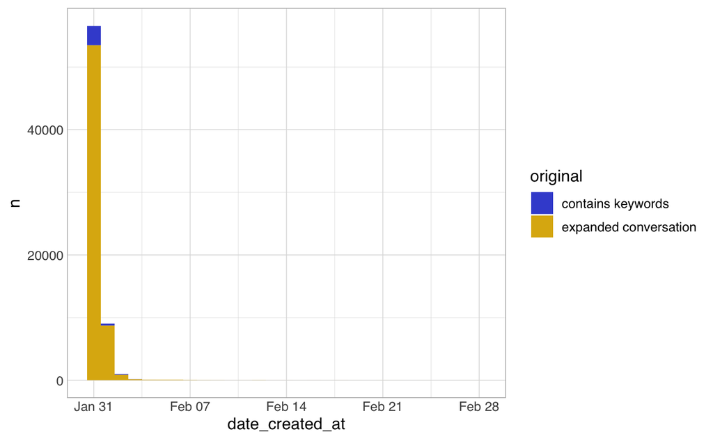

```r
tweets_c %>%
  filter(ur_conversation_id==sql("1488162322187182085")) %>%
  filter(created_at<"2022-03-01") %>%
  count(original,date_created_at) %>%
  collect() %>%
  mutate(original=if_else(original==1,"contains keywords","expanded conversation")) %>%
  ggplot(aes(x=date_created_at,y=n,fill=original)) +
  geom_col(width=1,position = 'stack') +
  theme_hsci_discrete()
```

### Top hashtags per year

```r
tweets_c %>%
  filter(ur_conversation_id==sql("1488162322187182085")) %>%
  left_join(tweet_hashtags_c,by=c("tweet_id")) %>%
  count(hashtag,year_created_at) %>%
  group_by(year_created_at) %>%
  slice_max(n,n=10) %>%
  gt(groupname_col="year_created_at",rowname_col="hashtag")
```

|  | n |
| --- | --- |
| 2022 |  |
| NA | 62406 |
| HONKHONK | 1197 |
| TruckersForFreedom2022 | 520 |
| TrudeauIsACoward | 484 |
| FreedomConvoy2022 | 202 |
| FreedomConvoyCanada2022 | 198 |
| Coward19 | 190 |
| HONK | 179 |
| CanadaTruckers | 156 |
| CowardOfTheCottage | 155 |

## Conversation 1225501300789477377: The British Slugfest

```r
tweets_c_i %>%
  filter(ur_conversation_id==sql("1225501300789477377")) %>%
  summarize(
    tweets=n(),
    tweets_with_keywords=sum(original),
    authors=n_distinct(author_id),
    min_date=min(created_at),
    max_date=max(created_at)
  ) %>% collect() %>%
  bind_cols(
    tweets_c_i %>%
      filter(ur_conversation_id==sql("1225501300789477377")) %>%
      count(author_id,name="tweets_per_author") %>%
      mutate(m_t_p_a=mean(tweets_per_author)) %>%
      summarize(mean_tweets_per_author=mean(tweets_per_author),tweets_per_author_mean_absolute_deviation=mean(abs(m_t_p_a-tweets_per_author))) %>% collect()
  ) %>%
  gt()
```

| tweets | tweets_with_keywords | authors | min_date | max_date | mean_tweets_per_author | tweets_per_author_mean_absolute_deviation |
| --- | --- | --- | --- | --- | --- | --- |
| 392561 | 63 | 2307 | 2020-02-06 19:27:03 | 2022-05-02 01:39:03 | 170.1608 | 310.278 |

### First 20 tweets

```r
tweets_c_i %>%
  filter(ur_conversation_id==sql("1225501300789477377")) %>%
  left_join(users_c_i,by=c("author_id"="user_id")) %>%
  arrange(created_at.x) %>%
  head(20) %>%
  mutate(tweet_id=str_c("[",tweet_id,"](https://twitter.com/a/status/",tweet_id,")")) %>%
  mutate(conversation_id=str_c("[",conversation_id,"](https://twitter.com/a/status/",conversation_id,")")) %>%
  mutate(ur_conversation_id=str_c("[",ur_conversation_id,"](https://twitter.com/a/status/",ur_conversation_id,")")) %>%
  gt() %>%
  fmt_markdown(tweet_id|conversation_id|ur_conversation_id)
```

| tweet_id | ur_conversation_id | conversation_id | author_id | created_at.x | retweet_count | reply_count | like_count | quote_count | lang | text | in_reply_to | in_reply_to_user_id | quotes | retweet_of | error.x | error_detail.x | original | hashtags | urls | mentions | children | ur_children | descendants | ur_descendants | leaf_descendants | ur_leaf_descendants | max_depth | ur_max_depth | t_authors | … |
| --- | --- | --- | --- | --- | --- | --- | --- | --- | --- | --- | --- | --- | --- | --- | --- | --- | --- | --- | --- | --- | --- | --- | --- | --- | --- | --- | --- | --- | --- | --- |
| 1225501300789477377 | 1225501300789477377 | 1225501300789477377 | 20675681 | 2020-02-06 19:27:03 | 1356 | 510 | 5387 | 127 | en | The name "England" is derived from the Old English name Englaland, which means "land of the Angles". The Angles were one of the Germanic tribes that settled in Great Britain during the Early Middle Ag… | NA | NA | NA | NA | NA | NA | 0 | NA | NA | NA | 432 | 433 | 806 | 807 | 560 | 561 | 26 | 26 | 546 | … |
| 1225501767380750340 | 1225501300789477377 | 1225501300789477377 | 1868174972 | 2020-02-06 19:29:02 | 0 | 0 | 1 | 0 | en | @JamesMelville Lala land right enough 😜 | 1225501300789477377 | 20675681 | NA | NA | NA | NA | 0 | NA | NA | 1 | 0 | 0 | 0 | 0 | 0 | 0 | 0 | 0 | 1 | … |
| 1225501785403674627 | 1225501300789477377 | 1225501300789477377 | 338272600 | 2020-02-06 19:29:02 | 0 | 3 | 8 | 0 | en | @JamesMelville And Scotland is land of a Northern Irish tribe! | 1225501300789477377 | 20675681 | NA | NA | NA | NA | 0 | NA | NA | 1 | 3 | 3 | 11 | 11 | 6 | 6 | 3 | 3 | 11 | … |
| 1225502011828981760 | 1225501300789477377 | 1225501300789477377 | 20675681 | 2020-02-06 19:30:02 | 15 | 5 | 83 | 0 | en | @rozzleberry Exactly this. https://twitter.com/JamesMelville/status/1225502011828981760/photo/1 | 1225501944023855104 | 28539960 | NA | NA | NA | NA | 0 | NA | 1 | NA | 5 | 5 | 5 | 5 | 5 | 5 | 1 | 1 | 6 | … |
| 1225502096243544065 | 1225501300789477377 | 1225501300789477377 | 219312033 | 2020-02-06 19:30:04 | 2 | 19 | 23 | 1 | en | @JamesMelville What’s your point James? Yes, we know Britain is a ‘Heinz 57’ variety. We’re leaving the EU, not planet Earth! | 1225501300789477377 | 20675681 | NA | NA | NA | NA | 0 | NA | NA | 1 | 17 | 17 | 46 | 46 | 27 | 27 | 5 | 5 | 32 | … |
| 1225502262212079617 | 1225501300789477377 | 1225501300789477377 | 2474355006 | 2020-02-06 19:31:02 | 2 | 4 | 33 | 0 | en | @JamesMelville And 3 lions on the shirt is a Norman ( French ) sigil | 1225501300789477377 | 20675681 | NA | NA | NA | NA | 0 | NA | NA | 1 | 4 | 4 | 7 | 7 | 5 | 5 | 2 | 2 | 8 | … |
| 1225502489233035265 | 1225501300789477377 | 1225501300789477377 | 1169138060262555650 | 2020-02-06 19:32:01 | 0 | 1 | 2 | 0 | en | @JamesMelville Yes and lots of Viking genes in the mix too, plus of course the French Norman invaders amongst others. And this great genetic mix has always been a great strength of this little country… | 1225501300789477377 | 20675681 | NA | NA | NA | NA | 0 | NA | NA | 1 | 1 | 1 | 2 | 2 | 1 | 1 | 2 | 2 | 2 | … |
| 1225502479330271234 | 1225501300789477377 | 1225501300789477377 | 20675681 | 2020-02-06 19:32:01 | 0 | 9 | 131 | 1 | en | @damianjbyrne I’m just pointing out an interesting historical fact. | 1225502096243544065 | 219312033 | NA | NA | NA | NA | 0 | NA | NA | 1 | 8 | 8 | 14 | 14 | 10 | 10 | 3 | 3 | 13 | … |
| 1225502630648188932 | 1225501300789477377 | 1225501300789477377 | 343048039 | 2020-02-06 19:32:05 | 0 | 1 | 0 | 0 | en | @JamesMelville Land of a German tribe is it? Would have loved to see you put that one past Alfred. | 1225501300789477377 | 20675681 | NA | NA | NA | NA | 0 | NA | NA | 1 | 1 | 1 | 5 | 5 | 1 | 1 | 5 | 5 | 2 | … |
| 1225502731940573189 | 1225501300789477377 | 1225501300789477377 | 1149379830858825730 | 2020-02-06 19:33:01 | 0 | 1 | 1 | 0 | en | @JamesMelville @schutzer9 time to wise up again I think BB | 1225501300789477377 | 20675681 | NA | NA | NA | NA | 0 | NA | NA | 2 | 1 | 1 | 1 | 1 | 1 | 1 | 1 | 1 | 2 | … |
| 1225502734167789568 | 1225501300789477377 | 1225501300789477377 | 219312033 | 2020-02-06 19:33:01 | 0 | 0 | 3 | 0 | en | @JamesMelville Sure 😉 | 1225502479330271234 | 20675681 | NA | NA | NA | NA | 0 | NA | NA | 1 | 0 | 0 | 0 | 0 | 0 | 0 | 0 | 0 | 1 | … |
| 1225502860860895234 | 1225501300789477377 | 1225501300789477377 | 902793353955348480 | 2020-02-06 19:33:04 | 0 | 1 | 4 | 0 | en | @damianjbyrne @JamesMelville Staggering lack of ambition there. | 1225502096243544065 | 219312033 | NA | NA | NA | NA | 0 | NA | NA | 2 | 1 | 1 | 1 | 1 | 1 | 1 | 1 | 1 | 2 | … |
| 1225502873942994945 | 1225501300789477377 | 1225501300789477377 | 438497121 | 2020-02-06 19:33:04 | 3 | 2 | 9 | 0 | en | @JamesMelville Isn’t Englaland a recent, popular musical film staring @BorisJohnson and @theresa_may ? #LALALAND | 1225501300789477377 | 20675681 | NA | NA | NA | NA | 0 | 1 | NA | 3 | 2 | 2 | 2 | 2 | 2 | 2 | 1 | 1 | 3 | … |
| 1225502952410025992 | 1225501300789477377 | 1225501300789477377 | 1149620099118055424 | 2020-02-06 19:34:00 | 0 | 1 | 2 | 0 | en | @JamesMelville And, even then, it wasn't a single, united entity. That didn't really even start until after the Normans decided to come visit. | 1225501300789477377 | 20675681 | NA | NA | NA | NA | 0 | NA | NA | 1 | 1 | 1 | 1 | 1 | 1 | 1 | 1 | 1 | 1 | … |
| 1225503053815652353 | 1225501300789477377 | 1225501300789477377 | 451443717 | 2020-02-06 19:34:03 | 1 | 5 | 6 | 1 | en | @JamesMelville Yes may i remind you also the Normans ( vikings) invaded 1066. It was a ruthless invasion killing all opposition and to this day they still own 80 percent of the land | 1225501300789477377 | 20675681 | NA | NA | NA | NA | 0 | NA | NA | 1 | 4 | 4 | 7 | 7 | 4 | 4 | 2 | 2 | 8 | … |
| 1225503238809620481 | 1225501300789477377 | 1225501300789477377 | 1109170109233487874 | 2020-02-06 19:35:01 | 1 | 3 | 9 | 0 | en | @Southside_Rog @JamesMelville One side. Pictish t'other and Norway over most. | 1225501785403674627 | 338272600 | NA | NA | NA | NA | 0 | NA | NA | 2 | 3 | 3 | 4 | 4 | 3 | 3 | 2 | 2 | 5 | … |
| 1225503259420483590 | 1225501300789477377 | 1225501300789477377 | 1149620099118055424 | 2020-02-06 19:35:02 | 0 | 0 | 2 | 0 | en | @JamesMelville Good ol' Norman and his conkers. | 1225502952410025992 | 1149620099118055424 | NA | NA | NA | NA | 0 | NA | NA | 1 | 0 | 0 | 0 | 0 | 0 | 0 | 0 | 0 | 1 | … |
| 1225503865031790592 | 1225501300789477377 | 1225501300789477377 | 1109170109233487874 | 2020-02-06 19:37:04 | 0 | 0 | 0 | 0 | en | @JamesMelville @kat_cary So that's why Mr Davis says the German car manufacturers are going to virtually pay us to take their cars so we can have an EU trade deal. We're all family. | 1225501300789477377 | 20675681 | NA | NA | NA | NA | 0 | NA | NA | 2 | 0 | 0 | 0 | 0 | 0 | 0 | 0 | 0 | 1 | … |
| 1225504479748984832 | 1225501300789477377 | 1225501300789477377 | 526291279 | 2020-02-06 19:40:01 | 1 | 1 | 1 | 0 | en | @JamesMelville So that will explain the obsession with German cars shoes and supermarkets then! | 1225501300789477377 | 20675681 | NA | NA | NA | NA | 0 | NA | NA | 1 | 1 | 1 | 1 | 1 | 1 | 1 | 1 | 1 | 2 | … |
| 1225504753830023170 | 1225501300789477377 | 1225501300789477377 | 25276598 | 2020-02-06 19:41:01 | 0 | 3 | 4 | 1 | en | @JamesMelville Just as the English language is actually derived from a German dialect. | 1225501300789477377 | 20675681 | NA | NA | NA | NA | 0 | NA | NA | 1 | 3 | 3 | 3 | 3 | 3 | 3 | 1 | 1 | 4 | … |

### Random 20 tweets

```r
tweets_c_i %>%
  filter(ur_conversation_id==sql("1225501300789477377")) %>%
  arrange(sql("RAND()")) %>%
  head(20) %>%
  arrange(created_at) %>%
  left_join(users_c_i,by=c("author_id"="user_id")) %>%
  mutate(tweet_id=str_c("[",tweet_id,"](https://twitter.com/a/status/",tweet_id,")")) %>%
  mutate(conversation_id=str_c("[",conversation_id,"](https://twitter.com/a/status/",conversation_id,")")) %>%
  mutate(ur_conversation_id=str_c("[",ur_conversation_id,"](https://twitter.com/a/status/",ur_conversation_id,")")) %>%
  gt() %>%
  fmt_markdown(tweet_id|conversation_id|ur_conversation_id)
```

| tweet_id | ur_conversation_id | conversation_id | author_id | created_at.x | retweet_count | reply_count | like_count | quote_count | lang | text | in_reply_to | in_reply_to_user_id | quotes | retweet_of | error.x | error_detail.x | original | hashtags | urls | mentions | children | ur_children | descendants | ur_descendants | leaf_descendants | ur_leaf_descendants | max_depth | ur_max_depth | t_authors | … |
| --- | --- | --- | --- | --- | --- | --- | --- | --- | --- | --- | --- | --- | --- | --- | --- | --- | --- | --- | --- | --- | --- | --- | --- | --- | --- | --- | --- | --- | --- | --- |
| 1482675424723357708 | 1225501300789477377 | 1225501300789477377 | 1460363862398717961 | 2022-01-16 11:25:04 | 0 | 1 | 3 | 0 | en | @SallyAnnC3 @Begentle50 @Mac_Paddy54 @LeftBehindPoet @David19531501 @GeoffBarton9 @ConraddKonnrad @BeowulfSchaefer @wanderer_bolton @resiguru @condimentset @boomer_ish @viv_cooper @HWick_Chris @Jimbo1… | 1482670222180077572 | 1236656550447591424 | NA | NA | NA | NA | 0 | NA | NA | 44 | 1 | 1 | 4 | 4 | 2 | 2 | 3 | 3 | 5 | … |
| 1482676944063942656 | 1225501300789477377 | 1225501300789477377 | 1591522008 | 2022-01-16 11:31:04 | 0 | 1 | 1 | 0 | en | @David19531501 @GeoffBarton9 @john30296891 @Begentle50 @SallyAnnC3 @Mac_Paddy54 @ConraddKonnrad @BeowulfSchaefer @wanderer_bolton @resiguru @condimentset @boomer_ish @viv_cooper @Claesson_Kate @HWick_… | 1482676835364311043 | 889538408237944833 | NA | NA | NA | NA | 0 | NA | NA | 44 | 1 | 1 | 1 | 1 | 1 | 1 | 1 | 1 | 2 | … |
| 1482674784739725315 | 1225501300789477377 | 1225501300789477377 | 1591522008 | 2022-01-16 11:23:01 | 0 | 1 | 1 | 0 | en | @David19531501 @Mac_Paddy54 @Begentle50 @GeoffBarton9 @ConraddKonnrad @BeowulfSchaefer @wanderer_bolton @resiguru @condimentset @boomer_ish @viv_cooper @Claesson_Kate @HWick_Chris @Jimbo12449841 @Andi… | 1482669240222113793 | 889538408237944833 | NA | NA | NA | NA | 0 | NA | NA | 44 | 1 | 1 | 1 | 1 | 1 | 1 | 1 | 1 | 2 | … |
| 1482675393266167818 | 1225501300789477377 | 1225501300789477377 | 1591522008 | 2022-01-16 11:25:03 | 0 | 0 | 0 | 0 | en | @john30296891 @Begentle50 @SallyAnnC3 @Mac_Paddy54 @David19531501 @GeoffBarton9 @ConraddKonnrad @BeowulfSchaefer @wanderer_bolton @resiguru @condimentset @boomer_ish @viv_cooper @Claesson_Kate @HWick_… | 1482675033805893634 | 1248538305341329409 | NA | NA | NA | NA | 0 | NA | NA | 44 | 0 | 0 | 0 | 0 | 0 | 0 | 0 | 0 | 1 | … |
| 1482676252146388992 | 1225501300789477377 | 1225501300789477377 | 1591522008 | 2022-01-16 11:28:05 | 0 | 0 | 0 | 0 | en | @GeoffBarton9 @john30296891 @Begentle50 @SallyAnnC3 @Mac_Paddy54 @David19531501 @ConraddKonnrad @BeowulfSchaefer @wanderer_bolton @resiguru @condimentset @boomer_ish @viv_cooper @Claesson_Kate @HWick_… | 1482676083333885952 | 1064245093408956416 | NA | NA | NA | NA | 0 | NA | NA | 44 | 0 | 0 | 0 | 0 | 0 | 0 | 0 | 0 | 1 | … |
| 1482671684096307200 | 1225501300789477377 | 1225501300789477377 | 889538408237944833 | 2022-01-16 11:10:05 | 0 | 2 | 0 | 0 | en | @LeftBehindPoet @Claesson_Kate @Mac_Paddy54 @Begentle50 @GeoffBarton9 @ConraddKonnrad @BeowulfSchaefer @wanderer_bolton @resiguru @condimentset @boomer_ish @viv_cooper @HWick_Chris @Jimbo12449841 @And… | 1482671479808475137 | 1591522008 | NA | NA | NA | NA | 0 | NA | NA | 44 | 2 | 2 | 7 | 7 | 3 | 3 | 4 | 4 | 4 | … |
| 1482675924042670083 | 1225501300789477377 | 1225501300789477377 | 889538408237944833 | 2022-01-16 11:27:04 | 0 | 0 | 2 | 0 | en | @john30296891 @LeftBehindPoet @Begentle50 @SallyAnnC3 @Mac_Paddy54 @GeoffBarton9 @ConraddKonnrad @BeowulfSchaefer @wanderer_bolton @resiguru @condimentset @boomer_ish @viv_cooper @Claesson_Kate @HWick… | 1482675033805893634 | 1248538305341329409 | NA | NA | NA | NA | 0 | NA | NA | 44 | 0 | 0 | 0 | 0 | 0 | 0 | 0 | 0 | 1 | … |
| 1482676835364311043 | 1225501300789477377 | 1225501300789477377 | 889538408237944833 | 2022-01-16 11:31:01 | 0 | 2 | 3 | 0 | en | @GeoffBarton9 @john30296891 @LeftBehindPoet @Begentle50 @SallyAnnC3 @Mac_Paddy54 @ConraddKonnrad @BeowulfSchaefer @wanderer_bolton @resiguru @condimentset @boomer_ish @viv_cooper @Claesson_Kate @HWick… | 1482676083333885952 | 1064245093408956416 | NA | NA | NA | NA | 0 | NA | NA | 44 | 2 | 2 | 5 | 5 | 2 | 2 | 3 | 3 | 4 | … |
| 1482677286931509250 | 1225501300789477377 | 1225501300789477377 | 889538408237944833 | 2022-01-16 11:33:00 | 0 | 0 | 2 | 0 | en | @LeftBehindPoet @GeoffBarton9 @john30296891 @Begentle50 @SallyAnnC3 @Mac_Paddy54 @ConraddKonnrad @BeowulfSchaefer @wanderer_bolton @resiguru @condimentset @boomer_ish @viv_cooper @Claesson_Kate @HWick… | 1482676944063942656 | 1591522008 | NA | NA | NA | NA | 0 | NA | NA | 44 | 0 | 0 | 0 | 0 | 0 | 0 | 0 | 0 | 1 | … |
| 1482271175698960387 | 1225501300789477377 | 1225501300789477377 | 1380517743057891329 | 2022-01-15 08:39:02 | 0 | 2 | 0 | 0 | en | @Chris_not_a_bot @condimentset @wanderer_bolton @resiguru @boomer_ish @viv_cooper @LeftBehindPoet @Claesson_Kate @Begentle50 @GeoffBarton9 @HWick_Chris @AndieHalihan @SallyAnnC3 @GeoffreyKeey @Conradd… | 1482148807542513665 | 1096435776076873730 | NA | NA | NA | NA | 0 | NA | 1 | 44 | 2 | 2 | 9 | 9 | 4 | 4 | 4 | 4 | 7 | … |
| 1482677482016890880 | 1225501300789477377 | 1225501300789477377 | 747159120046923776 | 2022-01-16 11:33:05 | 0 | 0 | 4 | 0 | en | @SallyAnnC3 @Mac_Paddy54 @LeftBehindPoet @David19531501 @GeoffBarton9 @ConraddKonnrad @BeowulfSchaefer @wanderer_bolton @resiguru @condimentset @boomer_ish @viv_cooper @Claesson_Kate @HWick_Chris @Jim… | 1482676863650648067 | 1236656550447591424 | NA | NA | NA | NA | 0 | NA | NA | 44 | 0 | 0 | 0 | 0 | 0 | 0 | 0 | 0 | 1 | … |
| 1482667773339840513 | 1225501300789477377 | 1225501300789477377 | 747159120046923776 | 2022-01-16 10:55:01 | 0 | 4 | 4 | 0 | en | @Mac_Paddy54 @LeftBehindPoet @David19531501 @GeoffBarton9 @ConraddKonnrad @BeowulfSchaefer @wanderer_bolton @resiguru @condimentset @boomer_ish @viv_cooper @Claesson_Kate @HWick_Chris @Jimbo12449841 @… | 1482667298808811529 | 1223721296040812545 | NA | NA | NA | NA | 0 | NA | NA | 44 | 3 | 3 | 318 | 318 | 116 | 116 | 39 | 39 | 25 | … |
| 1482670830446333952 | 1225501300789477377 | 1225501300789477377 | 747159120046923776 | 2022-01-16 11:07:02 | 0 | 5 | 3 | 0 | en | @SallyAnnC3 @Mac_Paddy54 @LeftBehindPoet @David19531501 @GeoffBarton9 @ConraddKonnrad @BeowulfSchaefer @wanderer_bolton @resiguru @condimentset @boomer_ish @viv_cooper @Claesson_Kate @HWick_Chris @Jim… | 1482670222180077572 | 1236656550447591424 | NA | NA | NA | NA | 0 | NA | NA | 44 | 5 | 5 | 281 | 281 | 104 | 104 | 35 | 35 | 25 | … |
| 1482672790201380866 | 1225501300789477377 | 1225501300789477377 | 747159120046923776 | 2022-01-16 11:15:01 | 0 | 3 | 4 | 0 | en | @SallyAnnC3 @Mac_Paddy54 @LeftBehindPoet @David19531501 @GeoffBarton9 @ConraddKonnrad @BeowulfSchaefer @wanderer_bolton @resiguru @condimentset @boomer_ish @viv_cooper @Claesson_Kate @HWick_Chris @Jim… | 1482672391788580867 | 1236656550447591424 | NA | NA | NA | NA | 0 | NA | NA | 45 | 3 | 3 | 268 | 268 | 98 | 98 | 33 | 33 | 24 | … |
| 1482635774852050949 | 1225501300789477377 | 1225501300789477377 | 1064245093408956416 | 2022-01-16 08:48:00 | 0 | 2 | 0 | 0 | en | @LeftBehindPoet @ConraddKonnrad @Begentle50 @BeowulfSchaefer @wanderer_bolton @resiguru @condimentset @boomer_ish @viv_cooper @Claesson_Kate @HWick_Chris @Jimbo12449841 @AndieHalihan @SallyAnnC3 @Geof… | 1482635350627524614 | 1591522008 | NA | NA | NA | NA | 0 | NA | NA | 44 | 2 | 2 | 85 | 85 | 23 | 23 | 31 | 31 | 12 | … |
| 1482676083333885952 | 1225501300789477377 | 1225501300789477377 | 1064245093408956416 | 2022-01-16 11:28:01 | 0 | 2 | 3 | 0 | en | @john30296891 @LeftBehindPoet @Begentle50 @SallyAnnC3 @Mac_Paddy54 @David19531501 @ConraddKonnrad @BeowulfSchaefer @wanderer_bolton @resiguru @condimentset @boomer_ish @viv_cooper @Claesson_Kate @HWic… | 1482675033805893634 | 1248538305341329409 | NA | NA | NA | NA | 0 | NA | NA | 44 | 2 | 2 | 7 | 7 | 3 | 3 | 4 | 4 | 5 | … |
| 1482677180102594561 | 1225501300789477377 | 1225501300789477377 | 904097911209938948 | 2022-01-16 11:32:04 | 0 | 1 | 2 | 0 | en | @Claesson_Kate @SallyAnnC3 @Begentle50 @Mac_Paddy54 @LeftBehindPoet @David19531501 @GeoffBarton9 @ConraddKonnrad @BeowulfSchaefer @resiguru @condimentset @boomer_ish @viv_cooper @HWick_Chris @Jimbo124… | 1482675424723357708 | 1460363862398717961 | NA | NA | NA | NA | 0 | NA | NA | 44 | 1 | 1 | 3 | 3 | 2 | 2 | 2 | 2 | 4 | … |
| 1482676863650648067 | 1225501300789477377 | 1225501300789477377 | 1236656550447591424 | 2022-01-16 11:31:02 | 0 | 2 | 6 | 0 | en | @Begentle50 @Mac_Paddy54 @LeftBehindPoet @David19531501 @GeoffBarton9 @ConraddKonnrad @BeowulfSchaefer @wanderer_bolton @resiguru @condimentset @boomer_ish @viv_cooper @Claesson_Kate @HWick_Chris @Jim… | 1482673694472380416 | 747159120046923776 | NA | NA | NA | NA | 0 | NA | NA | 44 | 2 | 2 | 4 | 4 | 2 | 2 | 3 | 3 | 4 | … |
| 1482399648631463938 | 1225501300789477377 | 1225501300789477377 | 3063944812 | 2022-01-15 17:09:05 | 0 | 6 | 1 | 0 | en | @susan04071 @SallyAnnC3 @Mac_Paddy54 @ChrisEv06631592 @LeftBehindPoet @of_flocks @MattAdkin @viv_cooper @AndieHalihan @Begentle50 @resiguru @BeowulfSchaefer @wanderer_bolton @condimentset @boomer_ish … | 1482398661971693571 | 2232735721 | NA | NA | NA | NA | 0 | NA | 1 | 44 | 6 | 6 | 8 | 8 | 6 | 6 | 2 | 2 | 9 | … |
| 1482392530524295175 | 1225501300789477377 | 1225501300789477377 | 1271732926636527616 | 2022-01-15 16:41:03 | 0 | 2 | 2 | 0 | en | @ConraddKonnrad @LeftBehindPoet @of_flocks @MattAdkin @viv_cooper @AndieHalihan @Begentle50 @resiguru @BeowulfSchaefer @wanderer_bolton @condimentset @boomer_ish @Claesson_Kate @GeoffBarton9 @HWick_Ch… | 1482391898111283203 | 3063944812 | NA | NA | NA | NA | 0 | NA | NA | 44 | 2 | 2 | 382 | 382 | 153 | 153 | 38 | 38 | 32 | … |

### Temporal extent

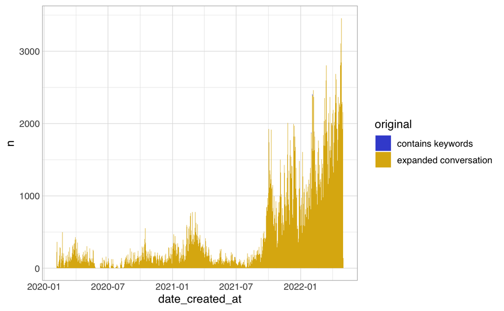

```r
tweets_c %>%
  filter(ur_conversation_id==sql("1225501300789477377")) %>%
  count(original,date_created_at) %>%
  collect() %>%
  mutate(original=if_else(original==1,"contains keywords","expanded conversation")) %>%
  ggplot(aes(x=date_created_at,y=n,fill=original)) +
  geom_col(width=1,position = 'stack') +
  theme_hsci_discrete()
```

### Top hashtags per year

```r
tweets_c %>%
  filter(ur_conversation_id==sql("1225501300789477377")) %>%
  left_join(tweet_hashtags_c,by=c("tweet_id")) %>%
  count(hashtag,year_created_at) %>%
  group_by(year_created_at) %>%
  slice_max(n,n=10) %>%
  gt(groupname_col="year_created_at",rowname_col="hashtag")
```

|  | n |
| --- | --- |
| 2020 |  |
| NA | 38105 |
| Brexit | 79 |
| brexiteer | 62 |
| ConnedByToffs | 56 |
| Brexiteers | 38 |
| littleEngland | 35 |
| ReleaseTheRussiaReport | 26 |
| littleEnglander | 21 |
| lyingtory | 20 |
| irony | 19 |
| 2021 |  |
| NA | 153781 |
| brexit | 111 |
| NorthShropshire | 93 |
| irony | 64 |
| number10party | 58 |
| FBPE | 58 |
| ConnedByToffs | 52 |
| RejoinEU | 30 |
| LibdemNazijibe | 29 |
| simplesibley | 23 |
| 2022 |  |
| NA | 193567 |
| Brexit | 82 |
| saltyfact | 56 |
| Leave | 43 |
| BoJo | 43 |
| Ukraine | 37 |
| TitanicBoris | 34 |
| EU | 25 |
| DefundTheBBc | 25 |
| brexiterplayingthevictimalert | 24 |
| Trump | 24 |

## Conversation 1485881808747220996: random ur-conversation 1

```r
ur_conversation_id_key <- "1485881808747220996"
tweets_c_i %>%
  filter(ur_conversation_id==sql(ur_conversation_id_key)) %>%
  summarize(
    tweets=n(),
    tweets_with_keywords=sum(original, na.rm=T),
    authors=n_distinct(author_id),
    min_date=min(created_at, na.rm=T),
    max_date=max(created_at, na.rm=T)
  ) %>% collect() %>%
  bind_cols(
    tweets_c_i %>%
      filter(ur_conversation_id==sql(ur_conversation_id_key)) %>%
      count(author_id,name="tweets_per_author") %>%
      mutate(m_t_p_a=mean(tweets_per_author, na.rm=T)) %>%
      summarize(mean_tweets_per_author=mean(tweets_per_author),tweets_per_author_mean_absolute_deviation=mean(abs(m_t_p_a-tweets_per_author))) %>% collect()
  ) %>%
  gt()
```

| tweets | tweets_with_keywords | authors | min_date | max_date | mean_tweets_per_author | tweets_per_author_mean_absolute_deviation |
| --- | --- | --- | --- | --- | --- | --- |
| 3 | 3 | 2 | 2022-01-25 07:46:04 | 2022-01-25 12:48:02 | 1.5 | 0.5 |

### First 20 tweets

```r
tweets_c_i %>%
  filter(ur_conversation_id==sql(ur_conversation_id_key)) %>%
  left_join(users_c_i,by=c("author_id"="user_id")) %>%
  arrange(created_at.x) %>%
  head(20) %>%
  mutate(tweet_id=str_c("[",tweet_id,"](https://twitter.com/a/status/",tweet_id,")")) %>%
  mutate(conversation_id=str_c("[",conversation_id,"](https://twitter.com/a/status/",conversation_id,")")) %>%
  mutate(ur_conversation_id=str_c("[",ur_conversation_id,"](https://twitter.com/a/status/",ur_conversation_id,")")) %>%
  gt() %>%
  fmt_markdown(tweet_id|conversation_id|ur_conversation_id)
```

| tweet_id | ur_conversation_id | conversation_id | author_id | created_at.x | retweet_count | reply_count | like_count | quote_count | lang | text | in_reply_to | in_reply_to_user_id | quotes | retweet_of | error.x | error_detail.x | original | hashtags | urls | mentions | children | ur_children | descendants | ur_descendants | leaf_descendants | ur_leaf_descendants | max_depth | ur_max_depth | t_authors | … |
| --- | --- | --- | --- | --- | --- | --- | --- | --- | --- | --- | --- | --- | --- | --- | --- | --- | --- | --- | --- | --- | --- | --- | --- | --- | --- | --- | --- | --- | --- | --- |
| 1485881808747220996 | 1485881808747220996 | 1485881808747220996 | 809793675882598400 | 2022-01-25 07:46:04 | 6 | 4 | 23 | 1 | en | This is the most absurd, most weird, most stupid thing I have ever seen. These guys not only railed against Jackson's motion but celebrated its defeat, but from the government. JLP urges gov't to enga… | NA | NA | NA | NA | NA | NA | 1 | NA | 1 | 1 | 1 | 1 | 1 | 2 | 1 | 2 | 1 | 2 | 1 | … |
| 1485948831699247104 | 1485881808747220996 | 1485881808747220996 | 809793675882598400 | 2022-01-25 12:13:00 | 2 | 0 | 7 | 0 | en | JLP leader Andrew Holness party is asking Prime Minister Holness' government to do something about a problem Prime Minister Holness and his MPs said was not a problem. Absurdity | 1485881808747220996 | 809793675882598400 | NA | NA | NA | NA | 1 | NA | NA | NA | 0 | 1 | 0 | 1 | 0 | 1 | 0 | 1 | 1 | … |
| 1485957720024965125 | 1485881808747220996 | 1485957720024965125 | 1185307579448283136 | 2022-01-25 12:48:02 | 2 | 0 | 0 | 0 | en | RT @ThompsonCanute: JLP leader Andrew Holness party is asking Prime Minister Holness' government to do something about a problem Prime Mini… | NA | NA | NA | 1485948831699247104 | NA | NA | 1 | NA | NA | 1 | 0 | 0 | 0 | 0 | 0 | 0 | 0 | 0 | 1 | … |

### Random 20 tweets

```r
tweets_c_i %>%
  filter(ur_conversation_id==sql(ur_conversation_id_key)) %>%
  arrange(sql("RAND()")) %>%
  head(20) %>%
  arrange(created_at) %>%
  left_join(users_c_i,by=c("author_id"="user_id")) %>%
  mutate(tweet_id=str_c("[",tweet_id,"](https://twitter.com/a/status/",tweet_id,")")) %>%
  mutate(conversation_id=str_c("[",conversation_id,"](https://twitter.com/a/status/",conversation_id,")")) %>%
  mutate(ur_conversation_id=str_c("[",ur_conversation_id,"](https://twitter.com/a/status/",ur_conversation_id,")")) %>%
  gt() %>%
  fmt_markdown(tweet_id|conversation_id|ur_conversation_id)
```

| tweet_id | ur_conversation_id | conversation_id | author_id | created_at.x | retweet_count | reply_count | like_count | quote_count | lang | text | in_reply_to | in_reply_to_user_id | quotes | retweet_of | error.x | error_detail.x | original | hashtags | urls | mentions | children | ur_children | descendants | ur_descendants | leaf_descendants | ur_leaf_descendants | max_depth | ur_max_depth | t_authors | … |
| --- | --- | --- | --- | --- | --- | --- | --- | --- | --- | --- | --- | --- | --- | --- | --- | --- | --- | --- | --- | --- | --- | --- | --- | --- | --- | --- | --- | --- | --- | --- |
| 1485948831699247104 | 1485881808747220996 | 1485881808747220996 | 809793675882598400 | 2022-01-25 12:13:00 | 2 | 0 | 7 | 0 | en | JLP leader Andrew Holness party is asking Prime Minister Holness' government to do something about a problem Prime Minister Holness and his MPs said was not a problem. Absurdity | 1485881808747220996 | 809793675882598400 | NA | NA | NA | NA | 1 | NA | NA | NA | 0 | 1 | 0 | 1 | 0 | 1 | 0 | 1 | 1 | … |
| 1485881808747220996 | 1485881808747220996 | 1485881808747220996 | 809793675882598400 | 2022-01-25 07:46:04 | 6 | 4 | 23 | 1 | en | This is the most absurd, most weird, most stupid thing I have ever seen. These guys not only railed against Jackson's motion but celebrated its defeat, but from the government. JLP urges gov't to enga… | NA | NA | NA | NA | NA | NA | 1 | NA | 1 | 1 | 1 | 1 | 1 | 2 | 1 | 2 | 1 | 2 | 1 | … |
| 1485957720024965125 | 1485881808747220996 | 1485957720024965125 | 1185307579448283136 | 2022-01-25 12:48:02 | 2 | 0 | 0 | 0 | en | RT @ThompsonCanute: JLP leader Andrew Holness party is asking Prime Minister Holness' government to do something about a problem Prime Mini… | NA | NA | NA | 1485948831699247104 | NA | NA | 1 | NA | NA | 1 | 0 | 0 | 0 | 0 | 0 | 0 | 0 | 0 | 1 | … |

### Temporal extent

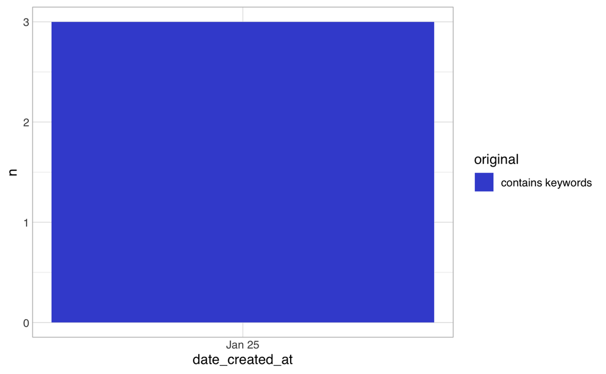

```r
tweets_c %>%
  filter(ur_conversation_id==sql(ur_conversation_id_key)) %>%
  count(original,date_created_at) %>%
  collect() %>%
  mutate(original=if_else(original==1,"contains keywords","expanded conversation")) %>%
  ggplot(aes(x=date_created_at,y=n,fill=original)) +
  geom_col(width=1,position = 'stack') +
  theme_hsci_discrete()
```

### Top hashtags per year

```r
tweets_c %>%
  filter(ur_conversation_id==sql(ur_conversation_id_key)) %>%
  left_join(tweet_hashtags_c,by=c("tweet_id")) %>%
  count(hashtag,year_created_at) %>%
  group_by(year_created_at) %>%
  slice_max(n,n=10) %>%
  gt(groupname_col="year_created_at",rowname_col="hashtag")
```

| n |
| --- |
| 2022 |
| 3 |

## Conversation 1485881813692149764: random ur-conversation 2

```r
ur_conversation_id_key <- "1485881813692149764"
tweets_c_i %>%
  filter(ur_conversation_id==sql(ur_conversation_id_key)) %>%
  summarize(
    tweets=n(),
    tweets_with_keywords=sum(original),
    authors=n_distinct(author_id),
    min_date=min(created_at),
    max_date=max(created_at)
  ) %>% collect() %>%
  bind_cols(
    tweets_c_i %>%
      filter(ur_conversation_id==sql(ur_conversation_id_key)) %>%
      count(author_id,name="tweets_per_author") %>%
      mutate(m_t_p_a=mean(tweets_per_author)) %>%
      summarize(mean_tweets_per_author=mean(tweets_per_author),tweets_per_author_mean_absolute_deviation=mean(abs(m_t_p_a-tweets_per_author))) %>% collect()
  ) %>%
  gt()
```

| tweets | tweets_with_keywords | authors | min_date | max_date | mean_tweets_per_author | tweets_per_author_mean_absolute_deviation |
| --- | --- | --- | --- | --- | --- | --- |
| 1 | 1 | 1 | 2022-01-25 07:46:04 | 2022-01-25 07:46:04 | 1 | 0 |

### First 20 tweets

```r
tweets_c_i %>%
  filter(ur_conversation_id==sql(ur_conversation_id_key)) %>%
  left_join(users_c_i,by=c("author_id"="user_id")) %>%
  arrange(created_at.x) %>%
  head(20) %>%
  mutate(tweet_id=str_c("[",tweet_id,"](https://twitter.com/a/status/",tweet_id,")")) %>%
  mutate(conversation_id=str_c("[",conversation_id,"](https://twitter.com/a/status/",conversation_id,")")) %>%
  mutate(ur_conversation_id=str_c("[",ur_conversation_id,"](https://twitter.com/a/status/",ur_conversation_id,")")) %>%
  gt() %>%
  fmt_markdown(tweet_id|conversation_id|ur_conversation_id)
```

| tweet_id | ur_conversation_id | conversation_id | author_id | created_at.x | retweet_count | reply_count | like_count | quote_count | lang | text | in_reply_to | in_reply_to_user_id | quotes | retweet_of | error.x | error_detail.x | original | hashtags | urls | mentions | children | ur_children | descendants | ur_descendants | leaf_descendants | ur_leaf_descendants | max_depth | ur_max_depth | t_authors | … |
| --- | --- | --- | --- | --- | --- | --- | --- | --- | --- | --- | --- | --- | --- | --- | --- | --- | --- | --- | --- | --- | --- | --- | --- | --- | --- | --- | --- | --- | --- | --- |
| 1485881813692149764 | 1485881813692149764 | 1485881813692149764 | 1443217850836008960 | 2022-01-25 07:46:04 | 0 | 0 | 0 | 0 | en | PM Modi interacts with Page Samiti members from Gujarat via NaMo App https://www.narendramodi.in/prime-minister-narendra-modi-s-interaction-with-page-samiti-members-from-gujarat-559639 https://twitter… | NA | NA | NA | NA | NA | NA | 1 | NA | 2 | NA | 0 | 0 | 0 | 0 | 0 | 0 | 0 | 0 | 1 | … |

### Random 20 tweets

```r
tweets_c_i %>%
  filter(ur_conversation_id==sql(ur_conversation_id_key)) %>%
  arrange(sql("RAND()")) %>%
  head(20) %>%
  arrange(created_at) %>%
  left_join(users_c_i,by=c("author_id"="user_id")) %>%
  mutate(tweet_id=str_c("[",tweet_id,"](https://twitter.com/a/status/",tweet_id,")")) %>%
  mutate(conversation_id=str_c("[",conversation_id,"](https://twitter.com/a/status/",conversation_id,")")) %>%
  mutate(ur_conversation_id=str_c("[",ur_conversation_id,"](https://twitter.com/a/status/",ur_conversation_id,")")) %>%
  gt() %>%
  fmt_markdown(tweet_id|conversation_id|ur_conversation_id)
```

| tweet_id | ur_conversation_id | conversation_id | author_id | created_at.x | retweet_count | reply_count | like_count | quote_count | lang | text | in_reply_to | in_reply_to_user_id | quotes | retweet_of | error.x | error_detail.x | original | hashtags | urls | mentions | children | ur_children | descendants | ur_descendants | leaf_descendants | ur_leaf_descendants | max_depth | ur_max_depth | t_authors | … |
| --- | --- | --- | --- | --- | --- | --- | --- | --- | --- | --- | --- | --- | --- | --- | --- | --- | --- | --- | --- | --- | --- | --- | --- | --- | --- | --- | --- | --- | --- | --- |
| 1485881813692149764 | 1485881813692149764 | 1485881813692149764 | 1443217850836008960 | 2022-01-25 07:46:04 | 0 | 0 | 0 | 0 | en | PM Modi interacts with Page Samiti members from Gujarat via NaMo App https://www.narendramodi.in/prime-minister-narendra-modi-s-interaction-with-page-samiti-members-from-gujarat-559639 https://twitter… | NA | NA | NA | NA | NA | NA | 1 | NA | 2 | NA | 0 | 0 | 0 | 0 | 0 | 0 | 0 | 0 | 1 | … |

### Temporal extent

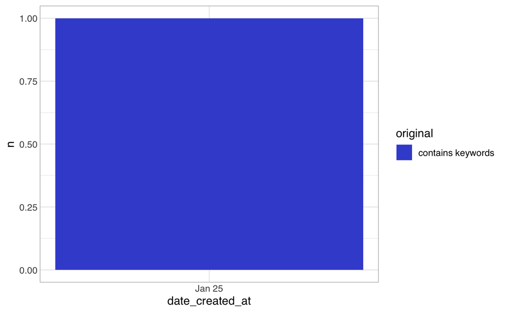

```r
tweets_c %>%
  filter(ur_conversation_id==sql(ur_conversation_id_key)) %>%
  count(original,date_created_at) %>%
  collect() %>%
  mutate(original=if_else(original==1,"contains keywords","expanded conversation")) %>%
  ggplot(aes(x=date_created_at,y=n,fill=original)) +
  geom_col(width=1,position = 'stack') +
  theme_hsci_discrete()
```

### Top hashtags per year

```r
tweets_c %>%
  filter(ur_conversation_id==sql(ur_conversation_id_key)) %>%
  left_join(tweet_hashtags_c,by=c("tweet_id")) %>%
  count(hashtag,year_created_at) %>%
  group_by(year_created_at) %>%
  slice_max(n,n=10) %>%
  gt(groupname_col="year_created_at",rowname_col="hashtag")
```

| n |
| --- |
| 2022 |
| 1 |

## Conversation 1485881842322612226: random ur-conversation 3

```r
ur_conversation_id_key <- "1485881842322612226"
tweets_c_i %>%
  filter(ur_conversation_id==sql(ur_conversation_id_key)) %>%
  summarize(
    tweets=n(),
    tweets_with_keywords=sum(original),
    authors=n_distinct(author_id),
    min_date=min(created_at),
    max_date=max(created_at)
  ) %>% collect() %>%
  bind_cols(
    tweets_c_i %>%
      filter(ur_conversation_id==sql(ur_conversation_id_key)) %>%
      count(author_id,name="tweets_per_author") %>%
      mutate(m_t_p_a=mean(tweets_per_author)) %>%
      summarize(mean_tweets_per_author=mean(tweets_per_author),tweets_per_author_mean_absolute_deviation=mean(abs(m_t_p_a-tweets_per_author))) %>% collect()
  ) %>%
  gt()
```

| tweets | tweets_with_keywords | authors | min_date | max_date | mean_tweets_per_author | tweets_per_author_mean_absolute_deviation |
| --- | --- | --- | --- | --- | --- | --- |
| 8 | 5 | 6 | 2022-01-25 07:46:05 | 2022-01-26 04:46:05 | 1.3333 | 0.4444333 |

### First 20 tweets

```r
tweets_c_i %>%
  filter(ur_conversation_id==sql(ur_conversation_id_key)) %>%
  left_join(users_c_i,by=c("author_id"="user_id")) %>%
  arrange(created_at.x) %>%
  head(20) %>%
  mutate(tweet_id=str_c("[",tweet_id,"](https://twitter.com/a/status/",tweet_id,")")) %>%
  mutate(conversation_id=str_c("[",conversation_id,"](https://twitter.com/a/status/",conversation_id,")")) %>%
  mutate(ur_conversation_id=str_c("[",ur_conversation_id,"](https://twitter.com/a/status/",ur_conversation_id,")")) %>%
  gt() %>%
  fmt_markdown(tweet_id|conversation_id|ur_conversation_id)
```

| tweet_id | ur_conversation_id | conversation_id | author_id | created_at.x | retweet_count | reply_count | like_count | quote_count | lang | text | in_reply_to | in_reply_to_user_id | quotes | retweet_of | error.x | error_detail.x | original | hashtags | urls | mentions | children | ur_children | descendants | ur_descendants | leaf_descendants | ur_leaf_descendants | max_depth | ur_max_depth | t_authors | … |
| --- | --- | --- | --- | --- | --- | --- | --- | --- | --- | --- | --- | --- | --- | --- | --- | --- | --- | --- | --- | --- | --- | --- | --- | --- | --- | --- | --- | --- | --- | --- |
| 1485881842322612226 | 1485881842322612226 | 1485881842322612226 | 1091288805494145024 | 2022-01-25 07:46:05 | 4 | 2 | 5 | 2 | en | Personalities think: Grace Tame controversy prime minister Scott Morrison on Australian of the Year https://www.emucoupon.com/australia/grace-tame-scott-morrison-controversy-australian-of-the-year #Sc… | NA | NA | NA | NA | NA | NA | 1 | 2 | 2 | NA | 2 | 6 | 3 | 7 | 2 | 6 | 2 | 2 | 4 | … |
| 1485882061340741634 | 1485881842322612226 | 1485882061340741634 | 1056851700013764608 | 2022-01-25 07:47:04 | 4 | 0 | 0 | 0 | en | RT @emucoupon: Personalities think: Grace Tame controversy prime minister Scott Morrison on Australian of the Year https://www.emucoupon.com/australia/grace-tame-scott-morrison-controversy-australian-… | NA | NA | NA | 1485881842322612226 | NA | NA | 1 | NA | 1 | 1 | 0 | 0 | 0 | 0 | 0 | 0 | 0 | 0 | 1 | … |
| 1485883076408393733 | 1485881842322612226 | 1485883076408393733 | 1453300371145777164 | 2022-01-25 07:51:04 | 4 | 0 | 0 | 0 | en | RT @emucoupon: Personalities think: Grace Tame controversy prime minister Scott Morrison on Australian of the Year https://www.emucoupon.com/australia/grace-tame-scott-morrison-controversy-australian-… | NA | NA | NA | 1485881842322612226 | NA | NA | 1 | NA | 1 | 1 | 0 | 0 | 0 | 0 | 0 | 0 | 0 | 0 | 1 | … |
| 1485883180360114179 | 1485881842322612226 | 1485883180360114179 | 1027528134772572160 | 2022-01-25 07:52:01 | 4 | 0 | 0 | 0 | en | RT @emucoupon: Personalities think: Grace Tame controversy prime minister Scott Morrison on Australian of the Year https://www.emucoupon.com/australia/grace-tame-scott-morrison-controversy-australian-… | NA | NA | NA | 1485881842322612226 | NA | NA | 1 | NA | 1 | 1 | 0 | 0 | 0 | 0 | 0 | 0 | 0 | 0 | 1 | … |
| 1485883443569385472 | 1485881842322612226 | 1485881842322612226 | 1453300371145777164 | 2022-01-25 07:53:01 | 0 | 0 | 1 | 0 | en | @emucoupon @CalTwomey @RileyBev @vmp9 Or more accurately which poltical party they vote fo | 1485881842322612226 | 1091288805494145024 | NA | NA | NA | NA | 0 | NA | NA | 4 | 0 | 0 | 0 | 0 | 0 | 0 | 0 | 0 | 1 | … |
| 1485884471090073600 | 1485881842322612226 | 1485884471090073600 | 1445267851791720449 | 2022-01-25 07:57:01 | 4 | 0 | 0 | 0 | en | RT @emucoupon: Personalities think: Grace Tame controversy prime minister Scott Morrison on Australian of the Year https://www.emucoupon.com/australia/grace-tame-scott-morrison-controversy-australian-… | NA | NA | NA | 1485881842322612226 | NA | NA | 1 | NA | 1 | 1 | 0 | 0 | 0 | 0 | 0 | 0 | 0 | 0 | 1 | … |
| 1485884893884256260 | 1485881842322612226 | 1485881842322612226 | 1437678627156541448 | 2022-01-25 07:58:05 | 0 | 1 | 2 | 0 | en | @emucoupon @CalTwomey @RileyBev @vmp9 Brave act by Grace | 1485881842322612226 | 1091288805494145024 | NA | NA | NA | NA | 0 | NA | NA | 4 | 1 | 1 | 1 | 1 | 1 | 1 | 1 | 1 | 2 | … |
| 1486198923379228673 | 1485881842322612226 | 1485881842322612226 | 1056851700013764608 | 2022-01-26 04:46:05 | 0 | 0 | 0 | 0 | en | @Elizabe69898841 @emucoupon @CalTwomey @RileyBev @vmp9 Grace Tame be like "🤬" https://twitter.com/WillSmi91862562/status/1486198923379228673/photo/1 | 1485884893884256260 | 1437678627156541448 | NA | NA | NA | NA | 0 | NA | 1 | 5 | 0 | 0 | 0 | 0 | 0 | 0 | 0 | 0 | 1 | … |

### Random 20 tweets

```r
tweets_c_i %>%
  filter(ur_conversation_id==sql(ur_conversation_id_key)) %>%
  arrange(sql("RAND()")) %>%
  head(20) %>%
  arrange(created_at) %>%
  left_join(users_c_i,by=c("author_id"="user_id")) %>%
  mutate(tweet_id=str_c("[",tweet_id,"](https://twitter.com/a/status/",tweet_id,")")) %>%
  mutate(conversation_id=str_c("[",conversation_id,"](https://twitter.com/a/status/",conversation_id,")")) %>%
  mutate(ur_conversation_id=str_c("[",ur_conversation_id,"](https://twitter.com/a/status/",ur_conversation_id,")")) %>%
  gt() %>%
  fmt_markdown(tweet_id|conversation_id|ur_conversation_id)
```

| tweet_id | ur_conversation_id | conversation_id | author_id | created_at.x | retweet_count | reply_count | like_count | quote_count | lang | text | in_reply_to | in_reply_to_user_id | quotes | retweet_of | error.x | error_detail.x | original | hashtags | urls | mentions | children | ur_children | descendants | ur_descendants | leaf_descendants | ur_leaf_descendants | max_depth | ur_max_depth | t_authors | … |
| --- | --- | --- | --- | --- | --- | --- | --- | --- | --- | --- | --- | --- | --- | --- | --- | --- | --- | --- | --- | --- | --- | --- | --- | --- | --- | --- | --- | --- | --- | --- |
| 1485884893884256260 | 1485881842322612226 | 1485881842322612226 | 1437678627156541448 | 2022-01-25 07:58:05 | 0 | 1 | 2 | 0 | en | @emucoupon @CalTwomey @RileyBev @vmp9 Brave act by Grace | 1485881842322612226 | 1091288805494145024 | NA | NA | NA | NA | 0 | NA | NA | 4 | 1 | 1 | 1 | 1 | 1 | 1 | 1 | 1 | 2 | … |
| 1485884471090073600 | 1485881842322612226 | 1485884471090073600 | 1445267851791720449 | 2022-01-25 07:57:01 | 4 | 0 | 0 | 0 | en | RT @emucoupon: Personalities think: Grace Tame controversy prime minister Scott Morrison on Australian of the Year https://www.emucoupon.com/australia/grace-tame-scott-morrison-controversy-australian-… | NA | NA | NA | 1485881842322612226 | NA | NA | 1 | NA | 1 | 1 | 0 | 0 | 0 | 0 | 0 | 0 | 0 | 0 | 1 | … |
| 1485881842322612226 | 1485881842322612226 | 1485881842322612226 | 1091288805494145024 | 2022-01-25 07:46:05 | 4 | 2 | 5 | 2 | en | Personalities think: Grace Tame controversy prime minister Scott Morrison on Australian of the Year https://www.emucoupon.com/australia/grace-tame-scott-morrison-controversy-australian-of-the-year #Sc… | NA | NA | NA | NA | NA | NA | 1 | 2 | 2 | NA | 2 | 6 | 3 | 7 | 2 | 6 | 2 | 2 | 4 | … |
| 1485883180360114179 | 1485881842322612226 | 1485883180360114179 | 1027528134772572160 | 2022-01-25 07:52:01 | 4 | 0 | 0 | 0 | en | RT @emucoupon: Personalities think: Grace Tame controversy prime minister Scott Morrison on Australian of the Year https://www.emucoupon.com/australia/grace-tame-scott-morrison-controversy-australian-… | NA | NA | NA | 1485881842322612226 | NA | NA | 1 | NA | 1 | 1 | 0 | 0 | 0 | 0 | 0 | 0 | 0 | 0 | 1 | … |
| 1485883076408393733 | 1485881842322612226 | 1485883076408393733 | 1453300371145777164 | 2022-01-25 07:51:04 | 4 | 0 | 0 | 0 | en | RT @emucoupon: Personalities think: Grace Tame controversy prime minister Scott Morrison on Australian of the Year https://www.emucoupon.com/australia/grace-tame-scott-morrison-controversy-australian-… | NA | NA | NA | 1485881842322612226 | NA | NA | 1 | NA | 1 | 1 | 0 | 0 | 0 | 0 | 0 | 0 | 0 | 0 | 1 | … |
| 1485883443569385472 | 1485881842322612226 | 1485881842322612226 | 1453300371145777164 | 2022-01-25 07:53:01 | 0 | 0 | 1 | 0 | en | @emucoupon @CalTwomey @RileyBev @vmp9 Or more accurately which poltical party they vote fo | 1485881842322612226 | 1091288805494145024 | NA | NA | NA | NA | 0 | NA | NA | 4 | 0 | 0 | 0 | 0 | 0 | 0 | 0 | 0 | 1 | … |
| 1485882061340741634 | 1485881842322612226 | 1485882061340741634 | 1056851700013764608 | 2022-01-25 07:47:04 | 4 | 0 | 0 | 0 | en | RT @emucoupon: Personalities think: Grace Tame controversy prime minister Scott Morrison on Australian of the Year https://www.emucoupon.com/australia/grace-tame-scott-morrison-controversy-australian-… | NA | NA | NA | 1485881842322612226 | NA | NA | 1 | NA | 1 | 1 | 0 | 0 | 0 | 0 | 0 | 0 | 0 | 0 | 1 | … |
| 1486198923379228673 | 1485881842322612226 | 1485881842322612226 | 1056851700013764608 | 2022-01-26 04:46:05 | 0 | 0 | 0 | 0 | en | @Elizabe69898841 @emucoupon @CalTwomey @RileyBev @vmp9 Grace Tame be like "🤬" https://twitter.com/WillSmi91862562/status/1486198923379228673/photo/1 | 1485884893884256260 | 1437678627156541448 | NA | NA | NA | NA | 0 | NA | 1 | 5 | 0 | 0 | 0 | 0 | 0 | 0 | 0 | 0 | 1 | … |

### Temporal extent

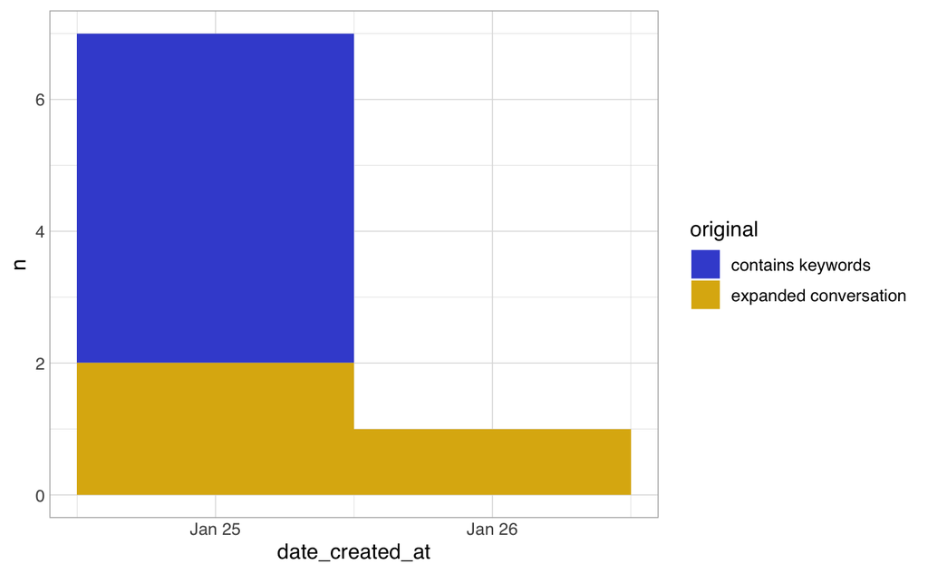

```r
tweets_c %>%
  filter(ur_conversation_id==sql(ur_conversation_id_key)) %>%
  count(original,date_created_at) %>%
  collect() %>%
  mutate(original=if_else(original==1,"contains keywords","expanded conversation")) %>%
  ggplot(aes(x=date_created_at,y=n,fill=original)) +
  geom_col(width=1,position = 'stack') +
  theme_hsci_discrete()
```

### Top hashtags per year

```r
tweets_c %>%
  filter(ur_conversation_id==sql(ur_conversation_id_key)) %>%
  left_join(tweet_hashtags_c,by=c("tweet_id")) %>%
  count(hashtag,year_created_at) %>%
  group_by(year_created_at) %>%
  slice_max(n,n=10) %>%
  gt(groupname_col="year_created_at",rowname_col="hashtag")
```

|  | n |
| --- | --- |
| 2022 |  |
| NA | 7 |
| AOTY | 1 |
| ScottyFromPhotoOps | 1 |